# Análisis Exploratorio de Datos (EDA) - Proyecto de Transporte

### Objetivos del Proyecto y Definición de Variables

El objetivo principal de este proyecto es desarrollar un modelo basado en **Máquinas de Vectores de Soporte (SVM)** para predecir el **modo de transporte** utilizado por un individuo en función de los datos recopilados por sensores de dispositivos móviles. Se busca analizar cómo las diferentes señales captadas por el acelerómetro, giróscopo, barómetro, GPS y magnetómetro pueden ser utilizadas para inferir con precisión el medio de transporte en uso.

Para lograr esto, se cuenta con un conjunto de datos que incluye:

1. **Registro Temporal**
   - Cada observación está asociada a un instante de tiempo específico.
2. **Datos de Movimiento y Orientación**
   - **Acelerómetro**: Componentes X, Y, Z del vector aceleración.
   - **Giróscopo**: Velocidad angular en los ejes X, Y, Z y su derivada.
   - **Matriz de Rotación y Cuaterniones**: Representan la orientación tridimensional del dispositivo.
3. **Datos de Ubicación y Contexto**
   - **GPS**: Coordenadas de latitud y longitud, velocidad, altitud y rumbo.
   - **Presión Atmosférica**: Valores obtenidos del barómetro, junto con la altitud relativa.
   - **Campo Magnético Terrestre**: Medición en los ejes X, Y, Z.
4. **Variables Categóricas**
   - **Modo de Transporte**: La categoría que se busca predecir (caminar, bicicleta, automóvil, etc.).
   - **Nivel de Confianza**: Un indicador de la precisión estimada para la clasificación del transporte en los datos originales.

### Alcance del Análisis

El análisis exploratorio de datos (EDA) busca comprender la estructura del dataset, identificar patrones y evaluar la calidad de los datos antes de proceder con el modelado. Se incluyen tareas como:

- **Identificación y tratamiento de outliers univariantes y multivariantes.**
- **Evaluación de la normalidad y distribución de las variables.**
- **Exploración de la correlación entre variables para determinar redundancias o relaciones clave.**
- **Selección de variables relevantes para el modelo.**

# **1. Carga de librerías**

```r
# Lista de paquetes necesarios
necessary_packages <- c("dplyr", "ggplot2", "DataExplorer", "naniar",
                        "moments", "psych", "caret", "lubridate", "chemometrics")

# Instalar paquetes que no están instalados
new_packages <- necessary_packages[!(necessary_packages %in% installed.packages()[, "Package"])]
if (length(new_packages) > 0) {
  install.packages(new_packages)
}

# Cargar todos los paquetes
lapply(necessary_packages, library, character.only = TRUE)
```

[output not shown]

```r
# Cargar las librerías
library(lubridate)
library(dplyr)
library(ggplot2)
library(naniar)
library(moments)
library(psych)
library(caret)
library(reshape2)
library(geosphere)
library(zoo)
# Cargar librerías necesarias
library(ggplot2)
library(gridExtra) # Para organizar múltiples gráficos
library(ggpubr)    # Para Q-Q plots
library(chemometrics)
```

# 2. Cargar el dataset

```r
# Ruta del archivo CSV (modificar según tu sistema)
ruta_dataset <- "C:/Users/Lenovo/Documents/IT Academy/Datos proyecto 8/proyect8/input_data/10Hz-v5-20230812-121154-303s-avion-despegue.csv"

data <- read.csv(ruta_dataset)

# Resumen del dataset
cat("### Información General del Dataset")
```

```
### Información General del Dataset
```

```r
dim(data) # Dimensiones del dataset
```

```
[1] 816  36
```

```r
str(data) # Estructura del dataset
```

```
'data.frame':   816 obs. of  36 variables:
 $ Timestamp               : chr  "12-Aug-2023 12:11:55.657" "12-Aug-2023 12:11:55.757" "12-Aug-2023 12:11:55.858" "12-Aug-2023 12:11:55.958" ...
 $ accelX.g.               : num  -0.0581 -0.0749 -0.0831 -0.0933 -0.0859 -0.0719 -0.0663 -0.0718 -0.0772 -0.0702 ...
 $ accelY.g.               : num  -0.499 -0.492 -0.489 -0.498 -0.486 ...
 $ accelZ.g.               : num  -0.826 -0.845 -0.846 -0.846 -0.859 ...
 $ accelUserX.g.           : num  0.0241 0.0095 0.0017 -0.0086 0.0029 0.0109 0.0149 0.0069 0.0009 0.0076 ...
 $ accelUserY.g.           : num  -0.0093 0.004 0.0017 -0.0099 -0.002 -0.0114 -0.0075 -0.0053 0.0059 0.0106 ...
 $ accelUserZ.g.           : num  0.0414 0.0244 0.0227 0.0246 0.0099 0.012 -0.0083 -0.0069 -0.0067 0.0146 ...
 $ gyroX.rad.s.            : num  0.0987 0.0801 -0.1333 -0.0636 -0.051 ...
 $ gyroY.rad.s.            : num  -0.0165 -0.0172 -0.0966 0.0199 0.0171 0.0375 0.0285 0.0482 0.0199 0.0173 ...
 $ gyroZ.rad.s.            : num  -0.0208 0.0406 -0.0158 -0.048 0.0057 -0.0044 -0.0015 -0.0046 0.0287 0.0265 ...
 $ Roll.rads.              : num  -0.0957 -0.0969 -0.0991 -0.0974 -0.0992 -0.0956 -0.0927 -0.0886 -0.0885 -0.0883 ...
 $ Pitch.rads.             : num  0.509 0.518 0.514 0.511 0.506 ...
 $ Yaw.rads.               : num  -1.36 -1.35 -1.35 -1.35 -1.35 ...
 $ m11                     : num  0.161 0.168 0.168 0.167 0.168 ...
```

[output cut: 22 more lines]

```r
summary(data) # Resumen estadístico básico
```

```
  Timestamp           accelX.g.          accelY.g.         accelZ.g.       accelUserX.g.       accelUserY.g.       accelUserZ.g.       gyroX.rad.s.       gyroY.rad.s.       gyroZ.rad.s.
 Length:816         Min.   :-0.28920   Min.   :-1.0336   Min.   :-1.1890   Min.   :-0.683400   Min.   :-0.370600   Min.   :-0.28760   Min.   :-1.08650   Min.   :-4.23680   Min.   :-6.74070
 Class :character   1st Qu.:-0.06212   1st Qu.:-0.4894   1st Qu.:-0.9408   1st Qu.:-0.011625   1st Qu.:-0.004025   1st Qu.:-0.02042   1st Qu.:-0.19390   1st Qu.:-0.09165   1st Qu.:-0.06600
 Mode  :character   Median :-0.01740   Median :-0.4032   Median :-0.8967   Median : 0.001350   Median : 0.005950   Median : 0.00640   Median :-0.04240   Median :-0.01210   Median :-0.01360
                    Mean   : 0.02692   Mean   :-0.3925   Mean   :-0.8130   Mean   : 0.006294   Mean   : 0.052098   Mean   : 0.02545   Mean   :-0.02564   Mean   : 0.03330   Mean   :-0.07281
                    3rd Qu.: 0.07700   3rd Qu.:-0.2490   3rd Qu.:-0.8246   3rd Qu.: 0.017900   3rd Qu.: 0.032050   3rd Qu.: 0.02615   3rd Qu.: 0.03470   3rd Qu.: 0.04770   3rd Qu.: 0.03920
                    Max.   : 2.04280   Max.   : 0.9630   Max.   : 0.5005   Max.   : 1.441200   Max.   : 1.063900   Max.   : 1.26200   Max.   : 5.01590   Max.   : 6.69320   Max.   : 4.88530
   Roll.rads.        Pitch.rads.        Yaw.rads.            m11                m12               m13                m21               m22                 m23               m31
 Min.   :-0.26330   Min.   :-0.9025   Min.   :-2.4852   Min.   :-0.92550   Min.   :-0.9852   Min.   :-0.95190   Min.   :-0.7168   Min.   :-0.928000   Min.   :-0.7849   Min.   :-0.9756
 1st Qu.:-0.07665   1st Qu.: 0.2531   1st Qu.:-2.0430   1st Qu.:-0.67540   1st Qu.:-0.8827   1st Qu.:-0.09102   1st Qu.:-0.4120   1st Qu.:-0.629050   1st Qu.: 0.2505   1st Qu.:-0.3588
 Median : 0.00620   Median : 0.4287   Median :-1.2723   Median :-0.48845   Median :-0.7630   Median :-0.00490   Median : 0.6876   Median :-0.418250   Median : 0.4157   Median :-0.2426
 Mean   : 0.10113   Mean   : 0.4434   Mean   :-0.2933   Mean   :-0.33923   Mean   :-0.2935   Mean   :-0.05980   Mean   : 0.3296   Mean   :-0.350829   Mean   : 0.4020   Mean   :-0.1077
 3rd Qu.: 0.11605   3rd Qu.: 0.5158   3rd Qu.: 2.5686   3rd Qu.: 0.07587   3rd Qu.: 0.4223   3rd Qu.: 0.06580   3rd Qu.: 0.8373   3rd Qu.:-0.005475   3rd Qu.: 0.4932   3rd Qu.: 0.0364
 Max.   : 1.64370   Max.   : 1.4767   Max.   : 2.9099   Max.   : 0.41070   Max.   : 0.9997   Max.   : 0.21670   Max.   : 0.9878   Max.   : 0.410600   Max.   : 0.9956   Max.   : 0.9765
      m32                m33                qX                 qY                qZ                qW          ActivityType       ActivityConfidence Pressure.kilopascals.
 Min.   :-0.54920   Min.   :-0.0522   Min.   :-0.31940   Min.   :-0.2307   Min.   :-0.8437   Min.   :-0.8194   Length:816         Length:816         Min.   :100.8
 1st Qu.:-0.07305   1st Qu.: 0.8215   1st Qu.:-0.06820   1st Qu.: 0.0485   1st Qu.:-0.5890   1st Qu.:-0.4002   Class :character   Class :character   1st Qu.:100.8
 Median : 0.21260   Median : 0.9007   Median : 0.02075   Median : 0.1562   Median : 0.6467   Median : 0.2356   Mode  :character   Mode  :character   Median :101.5
 Mean   : 0.12817   Mean   : 0.8140   Mean   : 0.06327   Mean   : 0.1228   Mean   : 0.3114   Mean   : 0.1508                                         Mean   :101.3
 3rd Qu.: 0.30402   3rd Qu.: 0.9493   3rd Qu.: 0.14452   3rd Qu.: 0.2254   3rd Qu.: 0.8900   3rd Qu.: 0.5998                                         3rd Qu.:101.6
 Max.   : 0.53210   Max.   : 0.9954   Max.   : 0.71580   Max.   : 0.4528   Max.   : 0.9753   Max.   : 0.8370                                         Max.   :101.7
 RelativeAltitude.meters.    magX.µT.          magY.µT.        magZ.µT.       calMagX.µT.       calMagY.µT.       calMagZ.µT.
 Min.   :-65.910          Min.   :-133.94   Min.   :265.6   Min.   :-441.7   Min.   :-27.470   Min.   :-49.550   Min.   :-41.14
 1st Qu.:-64.457          1st Qu.:-126.04   1st Qu.:294.2   1st Qu.:-439.1   1st Qu.:-19.145   1st Qu.:-20.612   1st Qu.:-38.62
 Median :-52.767          Median :-121.55   Median :316.1   Median :-434.1   Median :-12.807   Median :  1.247   Median :-33.85
 Mean   :-39.068          Mean   :-114.52   Mean   :307.9   Mean   :-430.2   Mean   : -6.627   Mean   : -7.069   Mean   :-30.16
 3rd Qu.:  1.205          3rd Qu.:-102.01   3rd Qu.:321.2   3rd Qu.:-430.6   3rd Qu.:  8.343   3rd Qu.:  5.595   3rd Qu.:-30.03
 Max.   :  1.702          Max.   : -71.24   Max.   :351.7   Max.   :-382.4   Max.   : 35.118   Max.   : 23.221   Max.   : 18.05
```

La variable `Timestamp` se encuentra en formato `chr` (cadena de texto), lo que requiere convertirla a un formato de fecha y hora (`POSIXct`) para facilitar su análisis temporal. Además, la columna `ActivityType` contiene valores desconocidos etiquetados como `unknown`, los cuales deben ser reemplazados y categorizados como `airplane` para garantizar la coherencia en los datos.

#### 2.1. Convertir Timestamp de chr

```r
head(data$Timestamp)
```

```
[1] "12-Aug-2023 12:11:55.657" "12-Aug-2023 12:11:55.757" "12-Aug-2023 12:11:55.858" "12-Aug-2023 12:11:55.958" "12-Aug-2023 12:11:56.059" "12-Aug-2023 12:11:56.159"
```

```r
# Convertir Timestamp con parse_date_time
data <- data %>%
  mutate(Timestamp = parse_date_time(Timestamp, orders = "dmy HMSOS"))

# Verificar el resultado
head(data$Timestamp)
```

```
[1] "2020-08-12 23:12:55 UTC" "2020-08-12 23:12:55 UTC" "2020-08-12 23:12:55 UTC" "2020-08-12 23:12:55 UTC" "2020-08-12 23:12:56 UTC" "2020-08-12 23:12:56 UTC"
```

```r
class(data$Timestamp)  # Debería ser POSIXct
```

```
[1] "POSIXct" "POSIXt"
```

### **2. Reemplazar valores `unknown` en `ActivityType` por `airplane`**

```r
# Reemplazar "unknown" por "airplane" en ActivityType
data <- data %>%
  mutate(ActivityType = if_else(ActivityType == "Unknown", "Airplane", ActivityType))

# Verificar los valores únicos de ActivityType
unique(data$ActivityType)
```

```
[1] "Airplane"
```

# 3. Estadísticas Descriptivas

Las estadísticas descriptivas ofrecen una visión inicial sobre el rango, la distribución y los valores típicos de las variables. Esto permite identificar patrones generales y posibles anomalías.

## **3.1 Variables Numéricas**

Se analizan las variables numéricas mediante histogramas y medidas descriptivas para evaluar su distribución y detectar valores atípicos.

```r
# Seleccionar columnas numéricas
num_data <- data %>% select(where(is.numeric))

# Verificar si hay columnas numéricas
if (ncol(num_data) > 0) {
  cat("### Estadísticas para Variables Numéricas\n")

  # Imprimir estadísticas descriptivas básicas
  print(describe(num_data)) # Estadísticas básicas

} else {
  cat("No hay variables numéricas en el dataset.\n")
}
```

```
### Estadísticas para Variables Numéricas
```

|  | vars | n | mean | sd | median | trimmed | mad | min | max | range | skew | kurtosis | se |
| --- | --- | --- | --- | --- | --- | --- | --- | --- | --- | --- | --- | --- | --- |
| accelX.g. | 1 | 816 | 0.03 | 0.22 | -0.02 | 0.00 | 0.09 | -0.29 | 2.04 | 2.33 | 6.24 | 52.14 | 0.01 |
| accelY.g. | 2 | 816 | -0.39 | 0.29 | -0.40 | -0.39 | 0.19 | -1.03 | 0.96 | 2.00 | 0.96 | 4.89 | 0.01 |
| accelZ.g. | 3 | 816 | -0.81 | 0.26 | -0.90 | -0.88 | 0.08 | -1.19 | 0.50 | 1.69 | 2.53 | 6.26 | 0.01 |
| accelUserX.g. | 4 | 816 | 0.01 | 0.18 | 0.00 | 0.00 | 0.02 | -0.68 | 1.44 | 2.12 | 2.15 | 27.96 | 0.01 |
| accelUserY.g. | 5 | 816 | 0.05 | 0.19 | 0.01 | 0.01 | 0.02 | -0.37 | 1.06 | 1.43 | 4.22 | 19.25 | 0.01 |
| accelUserZ.g. | 6 | 816 | 0.03 | 0.22 | 0.01 | 0.00 | 0.03 | -0.29 | 1.26 | 1.55 | 4.46 | 23.19 | 0.01 |
| gyroX.rad.s. | 7 | 816 | -0.03 | 0.55 | -0.04 | -0.07 | 0.15 | -1.09 | 5.02 | 6.10 | 5.40 | 44.44 | 0.02 |
| gyroY.rad.s. | 8 | 816 | 0.03 | 0.67 | -0.01 | -0.02 | 0.10 | -4.24 | 6.69 | 10.93 | 5.56 | 50.15 | 0.02 |
| gyroZ.rad.s. | 9 | 816 | -0.07 | 0.65 | -0.01 | -0.02 | 0.08 | -6.74 | 4.89 | 11.63 | -6.82 | 75.77 | 0.02 |
| Roll.rads. | 10 | 816 | 0.10 | 0.33 | 0.01 | 0.04 | 0.14 | -0.26 | 1.64 | 1.91 | 2.81 | 8.99 | 0.01 |

[output cut: 23 more lines]

```r
NA
```

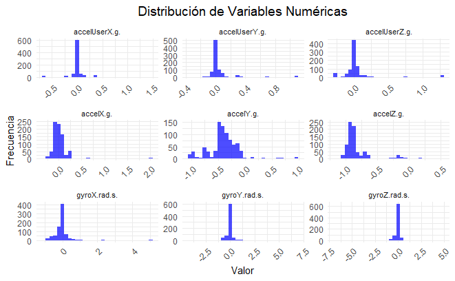

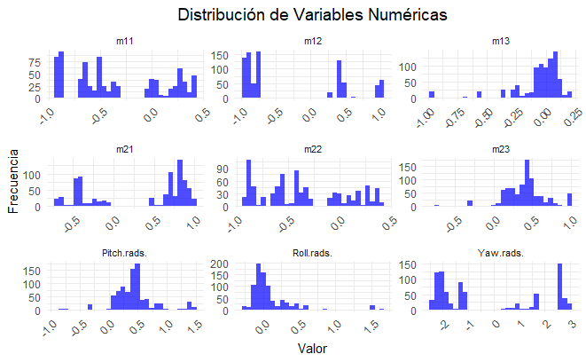

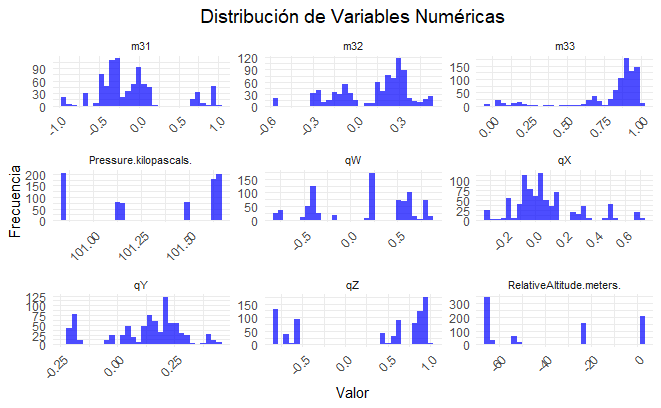

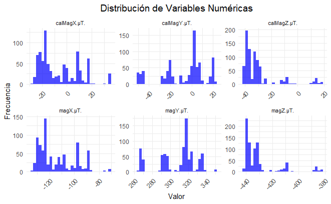

```r
# Instalar y cargar tidyr si es necesario
if (!requireNamespace("tidyr", quietly = TRUE)) {
  install.packages("tidyr")
}
library(tidyr)

# Visualización: Histogramas de Variables Numéricas
# Visualización: Histogramas de Variables Numéricas
# Dividir las variables en grupos de 9
variable_groups <- split(names(num_data), ceiling(seq_along(names(num_data)) / 9))

for (group in variable_groups) {
  # Filtrar las variables del grupo actual
  group_data <- num_data %>% select(all_of(group))

  # Convertir a formato largo
  group_data_long <- group_data %>%
    pivot_longer(cols = everything(), names_to = "Variable", values_to = "Valor")

  # Crear los gráficos
  print(
    ggplot(group_data_long, aes(x = Valor)) +
      geom_histogram(bins = 30, fill = "blue", alpha = 0.7) +
      facet_wrap(~ Variable, scales = "free", ncol = 3) +
      theme_minimal() +
      theme(
        strip.text = element_text(size = 8),
        axis.text.x = element_text(angle = 45, hjust = 1),
        plot.title = element_text(size = 14, hjust = 0.5)
      ) +
      labs(title = "Distribución de Variables Numéricas",
           x = "Valor",
           y = "Frecuencia")
  )
}
```

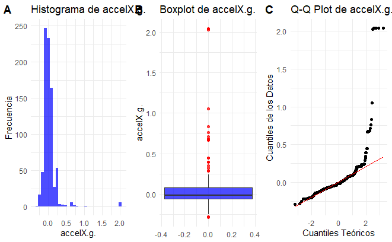

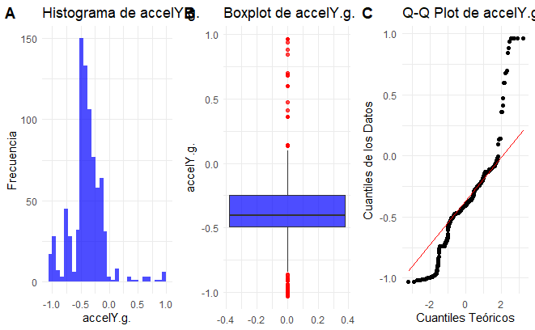

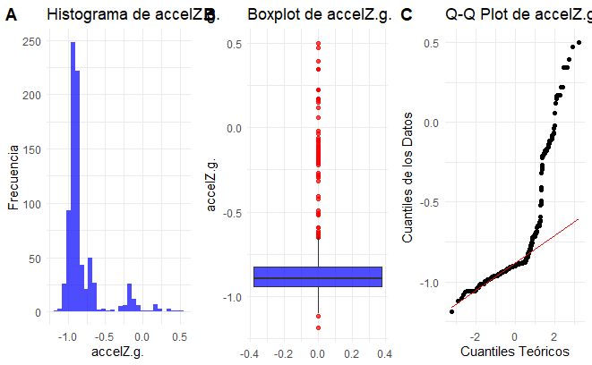

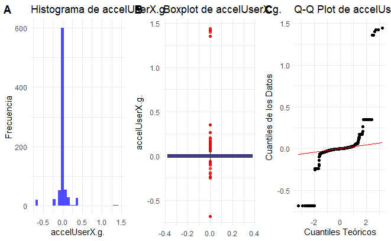

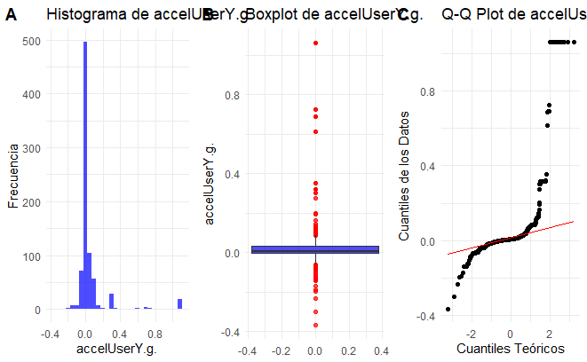

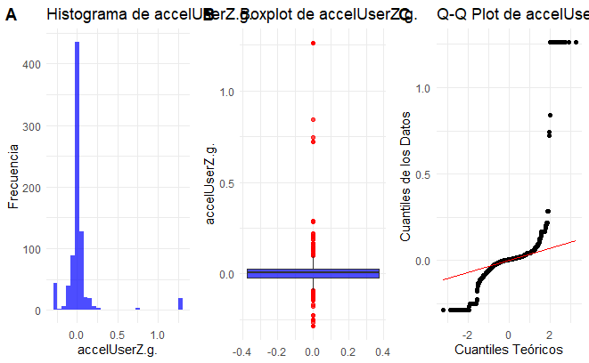

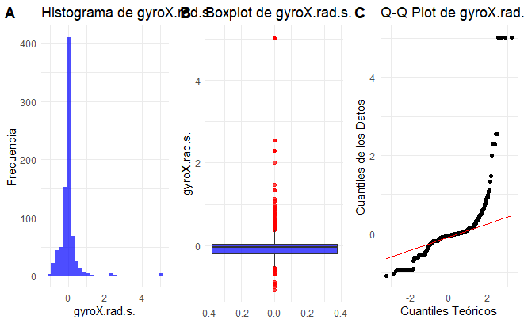

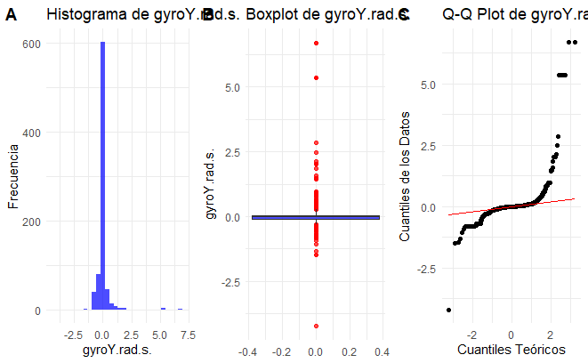

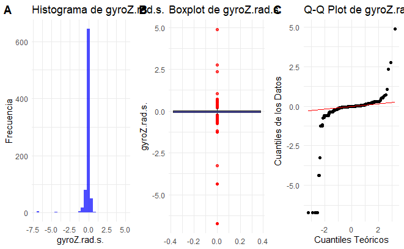

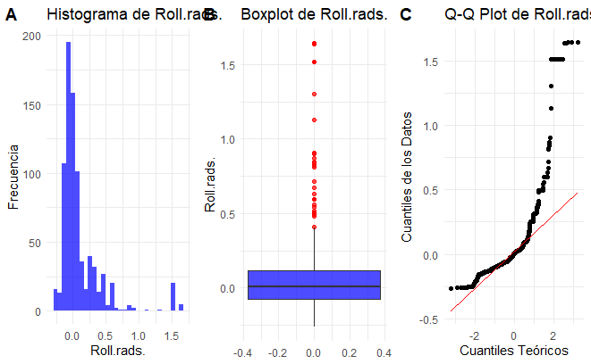

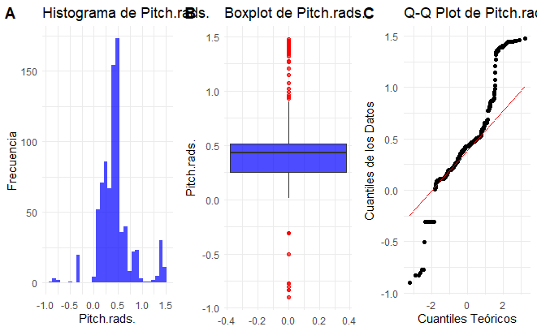

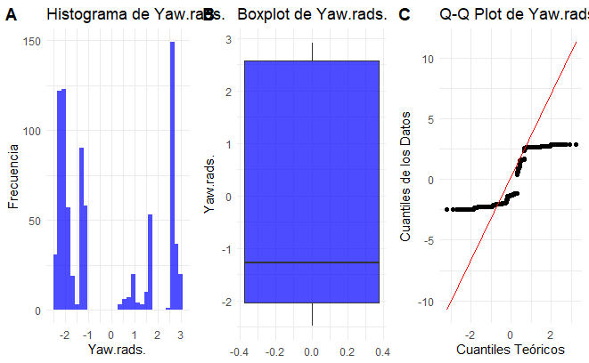

[21 more figures not shown]

```r
# Cargar librerías necesarias
if (!requireNamespace("tidyverse", quietly = TRUE)) install.packages("tidyverse")
if (!requireNamespace("cowplot", quietly = TRUE)) install.packages("cowplot")
library(tidyverse)
library(cowplot)

# Eliminar valores NA en num_data
num_data_clean <- num_data %>% drop_na()

# Confirmar que hay variables numéricas
if (ncol(num_data_clean) > 0) {
  # Iterar sobre las variables numéricas
  for (var in names(num_data_clean)) {
    # Crear histogramas
    hist_plot <- ggplot(num_data_clean, aes(x = !!sym(var))) +
      geom_histogram(bins = 30, fill = "blue", alpha = 0.7) +
      theme_minimal() +
      labs(title = paste("Histograma de", var), x = var, y = "Frecuencia")

    # Crear boxplots
    box_plot <- ggplot(num_data_clean, aes(y = !!sym(var))) +
      geom_boxplot(fill = "blue", alpha = 0.7, outlier.color = "red") +
      theme_minimal() +
      labs(title = paste("Boxplot de", var), y = var)

    # Crear Q-Q plots
    qq_plot <- ggplot(num_data_clean, aes(sample = !!sym(var))) +
      stat_qq() +
      stat_qq_line(color = "red") +
      theme_minimal() +
      labs(title = paste("Q-Q Plot de", var), x = "Cuantiles Teóricos", y = "Cuantiles de los Datos")

    # Mostrar los gráficos en una cuadrícula
    print(plot_grid(hist_plot, box_plot, qq_plot, ncol = 3, labels = c("A", "B", "C")))
  }
} else {
  cat("No hay variables numéricas en el dataset.\n")
}
```

```r
NA
NA
```

### 4. Curtosis

- **Distribuciones con Colas Pesadas**:
  - Variables como `gyroX.rad.s.` (Curtosis = 44.44) y `accelX.g.` (Curtosis = 52.14) tienen colas largas, sugiriendo la presencia de valores extremos.
- **Distribuciones Normalizadas**:
  - `m33` (Curtosis = 2.75) tiene una curtosis cercana a 3, indicando que su distribución es más cercana a la normal.

### 6. Recomendaciones

1. **Normalización y Escalado**:
   - Se recomienda escalar las variables con alta variabilidad para garantizar que todas las variables tengan el mismo peso en análisis posteriores.
2. **Revisión de Outliers**:
   - Identificar y tratar valores extremos en variables como `accelX.g.` y `gyroX.rad.s.`.
3. **Transformaciones**:
   - Variables como `accelX.g.` y `gyroY.rad.s.` podrían beneficiarse de transformaciones logarítmicas para estabilizar la varianza.
4. **Filtrado de Variables**:
   - Considerar eliminar variables con baja dispersión o alta redundancia para simplificar el modelo.

## 3.2 Variables Categóricas

Las variables categóricas se analizan para evaluar el balance de las clases, especialmente la variable objetivo.

```r
# Convertir la columna Timestamp a formato fecha y hora
data <- data %>%
  mutate(Timestamp = as.POSIXct(Timestamp, format = "%d-%b-%Y %H:%M:%OS"))

# Convertir las columnas character restantes en factor
data <- data %>%
  mutate(across(where(is.character), as.factor))

# Seleccionar las variables categóricas
cat_data <- data %>% select(where(is.factor))

# Verificar las estadísticas de variables categóricas
if (ncol(cat_data) > 0) {
  cat("### Estadísticas para Variables Categóricas\n")
  print(sapply(cat_data, table))
}
```

```
### Estadísticas para Variables Categóricas
 ActivityType.Airplane ActivityConfidence.Low
                   816                    816
```

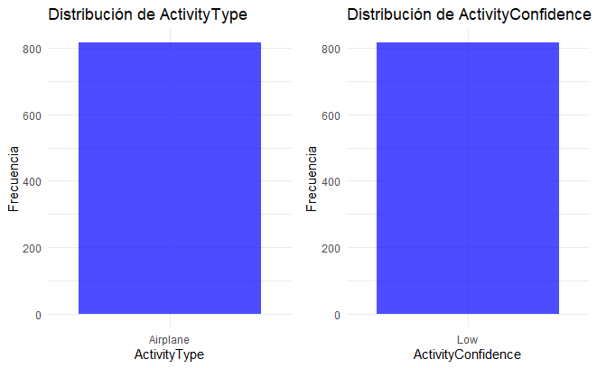

```r
# Gráficos de barras para cada variable categórica
# Crear una lista para almacenar los gráficos
plot_list <- list()

# Crear gráficos de barras para cada variable categórica y almacenarlos en la lista
for (var in names(cat_data)) {
  p <- ggplot(cat_data, aes_string(x = var)) +
    geom_bar(fill = "blue", alpha = 0.7) +
    theme_minimal() +
    labs(title = paste("Distribución de", var),
         x = var,
         y = "Frecuencia") +
    theme(axis.text.x = element_text(angle = 0, hjust = 0.5)) # Categorías horizontales

  # Agregar el gráfico a la lista
  plot_list[[var]] <- p
}

# Combinar todos los gráficos en una sola hoja
grid.arrange(grobs = plot_list, ncol = 2) # Ajusta ncol para cambiar las columnas
```

# 4. Análisis de Valores Faltantes y Outliers

## 4.1 Detección de Valores faltantes

Identificar valores faltantes es crucial porque pueden afectar el rendimiento del modelo predictivo. Este paso ayuda a decidir estrategias para imputar o manejar estos valores.

```r
cat("### Análisis de Valores Faltantes\n")
```

```
### Análisis de Valores Faltantes
```

```r
# Resumen de valores faltantes por columna
print(sapply(data, function(x) sum(is.na(x))))
```

```
               Timestamp                accelX.g.                accelY.g.                accelZ.g.            accelUserX.g.            accelUserY.g.            accelUserZ.g.
                       0                        0                        0                        0                        0                        0                        0
            gyroX.rad.s.             gyroY.rad.s.             gyroZ.rad.s.               Roll.rads.              Pitch.rads.                Yaw.rads.                      m11
                       0                        0                        0                        0                        0                        0                        0
                     m12                      m13                      m21                      m22                      m23                      m31                      m32
                       0                        0                        0                        0                        0                        0                        0
                     m33                       qX                       qY                       qZ                       qW             ActivityType       ActivityConfidence
                       0                        0                        0                        0                        0                        0                        0
   Pressure.kilopascals. RelativeAltitude.meters.                 magX.µT.                 magY.µT.                 magZ.µT.              calMagX.µT.              calMagY.µT.
                       0                        0                        0                        0                        0                        0                        0
             calMagZ.µT.
                       0
```

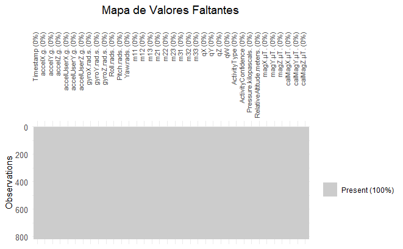

```r
# Visualización de valores faltantes mejorada
vis_miss(data) +
  ggtitle("Mapa de Valores Faltantes") +
  theme_minimal() +
  theme(
    axis.text.x = element_text(angle = 90, hjust = 1, size = 8), # Ajuste de las etiquetas del eje X
    axis.text.y = element_text(size = 10),                       # Ajuste de las etiquetas del eje Y
    plot.title = element_text(hjust = 0.5, size = 14)            # Centrar y ajustar tamaño del título
  )
```

```r
NA
NA
```

El análisis muestra que no hay valores nulos en el dataset. Esto significa que todas las variables contienen información completa para las 816 observaciones registradas. Este resultado asegura que no será necesario realizar técnicas de imputación de datos.

## 4.2 Detección de Outliers Univariantes

Usaremos el rango intercuartílico (IQR) para identificar outliers y calcular el porcentaje de valores extremos en cada variable numérica.

```r
if (ncol(num_data) > 0) {
  cat("### Análisis de Outliers\n")

  # Cálculo de outliers por IQR
  outlier_detection <- num_data %>%
    summarise(across(everything(), ~ {
      q1 <- quantile(.x, 0.25, na.rm = TRUE)
      q3 <- quantile(.x, 0.75, na.rm = TRUE)
      iqr <- q3 - q1
      sum(.x < (q1 - 1.5 * iqr) | .x > (q3 + 1.5 * iqr), na.rm = TRUE) / length(.x) * 100
    }))

  # Transponer la tabla
  outlier_detection <- as.data.frame(t(outlier_detection))
  outlier_detection$Variable <- rownames(outlier_detection)
  rownames(outlier_detection) <- NULL

  # Reordenar las columnas
  outlier_detection <- outlier_detection %>%
    select(Variable, `Outliers (%)` = V1) %>%
    arrange(desc(`Outliers (%)`))  # Ordenar de mayor a menor

  # Mostrar la tabla
  print(outlier_detection)
}
```

```
### Análisis de Outliers
```

| Variable | Outliers (%) |
| --- | --- |
| gyroZ.rad.s. | 20.2205882 |
| gyroY.rad.s. | 18.9950980 |
| accelUserZ.g. | 17.8921569 |
| accelUserX.g. | 16.2990196 |
| accelUserY.g. | 15.9313725 |
| magZ.µT. | 15.8088235 |
| m31 | 15.4411765 |
| gyroX.rad.s. | 15.3186275 |
| accelZ.g. | 13.2352941 |
| calMagZ.µT. | 12.9901961 |

[output cut: 23 more lines]

**Visualización de Outliers**

Utilizaremos boxplots para visualizar los outliers en cada variable numérica.

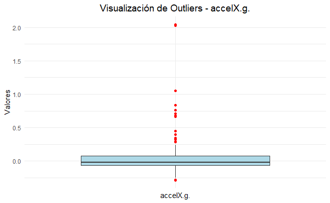

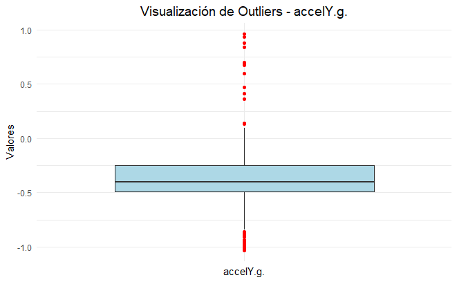

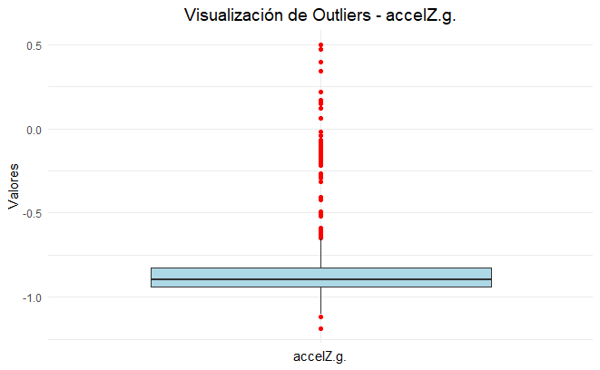

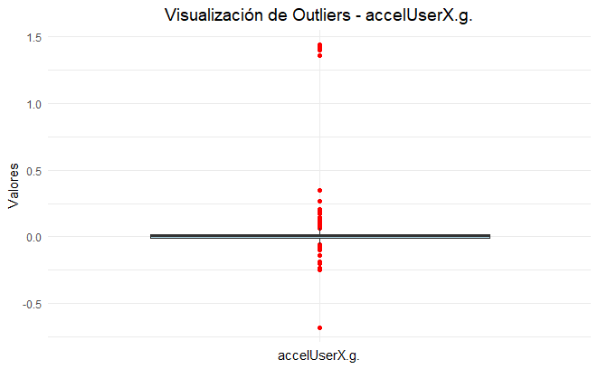

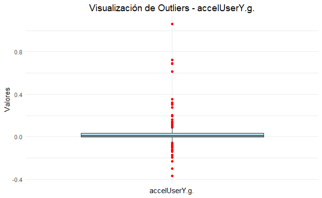

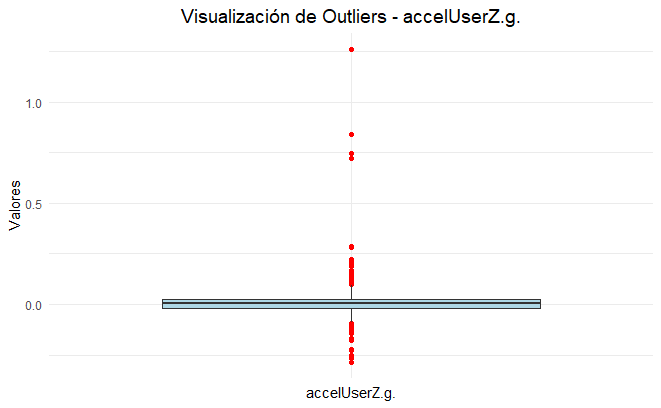

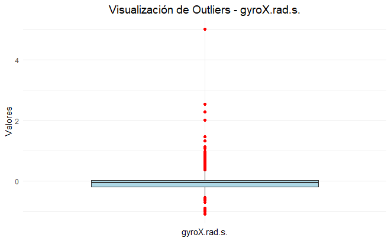

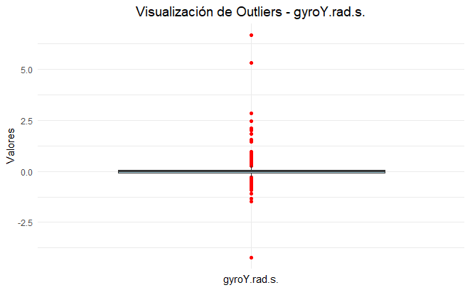

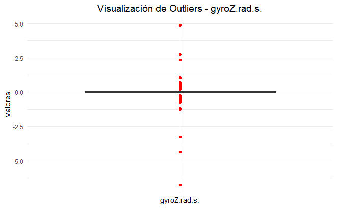

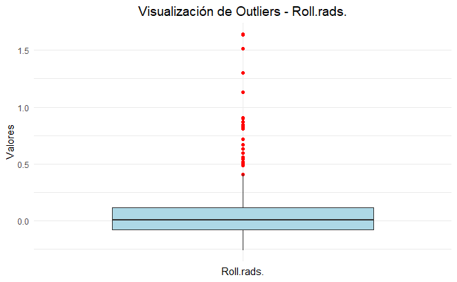

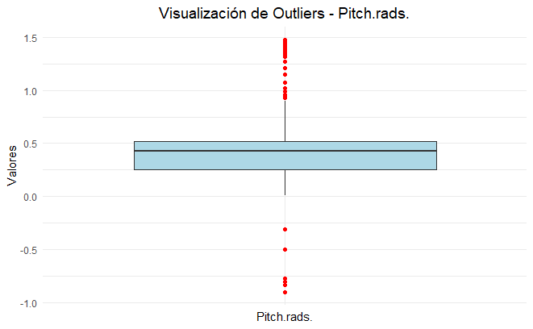

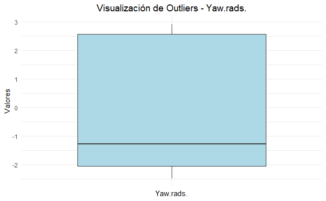

[21 more figures not shown]

```r
if (ncol(num_data) > 0) {
  # Transformar datos a formato largo
  num_data_long <- num_data %>%
    pivot_longer(cols = everything(), names_to = "Variable", values_to = "Valor")

  # Obtener las variables únicas
  unique_variables <- unique(num_data_long$Variable)

  # Crear gráficos individuales en un bucle
  for (var in unique_variables) {
    plot <- ggplot(num_data_long %>% filter(Variable == var), aes(x = Variable, y = Valor)) +
      geom_boxplot(outlier.colour = "red", outlier.size = 1.5, fill = "lightblue") +
      theme_minimal() +
      labs(
        title = paste("Visualización de Outliers -", var),
        x = var,
        y = "Valores"
      ) +
      theme(
        plot.title = element_text(size = 14, hjust = 0.5),
        axis.text.x = element_blank(),
        axis.ticks.x = element_blank()
      )

    # Usar print() explícito para mostrar cada gráfico
    print(plot)
  }
} else {
  cat("No hay variables numéricas en el dataset.\n")
}
```

```r
NA
NA
```

En el análisis univariado, se identificaron variables con un porcentaje significativo de outliers (>10%), lo que podría afectar el análisis y los resultados si no se gestionan adecuadamente. A continuación, se destacan las variables más críticas:

- **`gyroZ.rad.s.` (20.22%) y `gyroY.rad.s.` (18.99%)**: Representan velocidades angulares en los ejes Z e Y, afectadas por movimientos bruscos o ruidos del sensor durante el despegue. Se sugiere aplicar **winsorización** para limitar los valores extremos y reducir su impacto.
- **`accelUserX.g.` (16.29%) y `accelUserY.g.` (15.93%)**: Reflejan aceleraciones específicas medidas en los ejes X e Y. Los outliers pueden deberse a turbulencias o vibraciones. Se recomienda utilizar una **transformación logarítmica** para suavizar la distribución, o **winsorización** para conservar la estructura subyacente.
- **`magZ.µT.` (15.80%)**: Representa el campo magnético terrestre en el eje Z. Los valores extremos podrían estar relacionados con interferencias electromagnéticas cercanas al avión. Una estrategia viable es aplicar **winsorización** para mantener la continuidad de los datos.

Estas variables son fundamentales para el análisis del movimiento, estabilidad y entorno electromagnético del avión. Su correcta transformación, como**winsorización**, ayudará a mitigar el impacto de los valores extremos y mejorar la calidad del análisis.

## 4.3 Multivariate Outliers

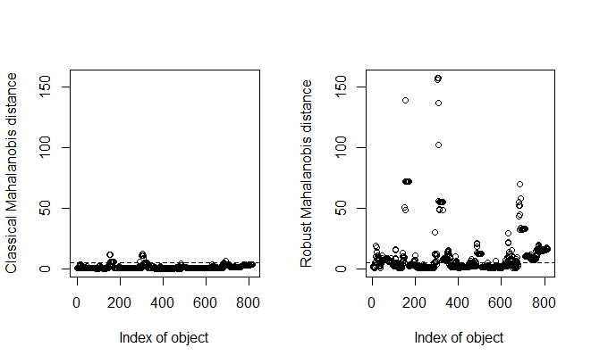

```r
# Cargar la librería
library(chemometrics)

# Crear una copia del dataset original para trabajar
data_analysis <- data

# Seleccionar las variables continuas con mayor porcentaje de outliers (>10%)
selected_vars <- data_analysis %>%
  select(gyroZ.rad.s., gyroY.rad.s., accelUserX.g., accelUserY.g., magZ.µT.)

# Calcular las distancias de Mahalanobis (clásica y robusta)
res.out <- Moutlier(selected_vars, quantile = 0.9999)
```

```r
# Inspeccionar resultados
str(res.out)
```

```
List of 3
 $ md    : num [1:816] 0.645 0.603 0.67 0.662 0.603 ...
 $ rd    : num [1:816] 1.962 1.222 1.193 1.573 0.785 ...
 $ cutoff: num 5.07
```

```r
# Visualizar outliers multivariantes
par(mfrow = c(1, 1)) # Una sola ventana de gráfico
plot(res.out$md, res.out$rd,
     xlab = "Mahalanobis Clásica",
     ylab = "Mahalanobis Robusta",
     main = "Outliers Multivariantes con Distancias de Mahalanobis")
abline(h = res.out$cutoff, col = "red") # Umbral robusto
```

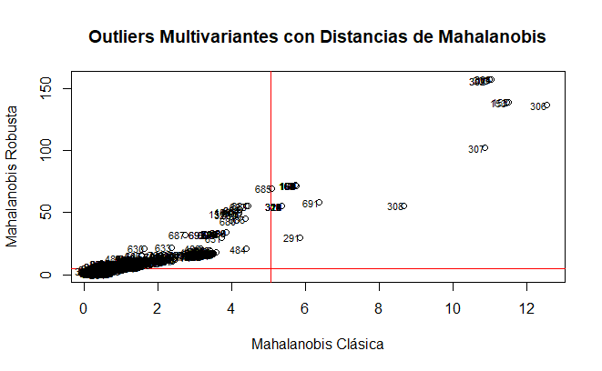

```r
abline(v = res.out$cutoff, col = "red") # Umbral clásico
text(res.out$md, res.out$rd, labels = rownames(data_analysis), adj = 1, cex = 0.7)
```

```r
# Identificar observaciones que son outliers multivariantes
outlier_indices <- which((res.out$md > res.out$cutoff) & (res.out$rd > res.out$cutoff))
cat("Observaciones outliers multivariantes:\n")
```

```
Observaciones outliers multivariantes:
```

```r
print(outlier_indices)
```

```
 [1] 152 153 154 155 156 157 158 159 160 161 162 163 164 165 166 167 168 169 170 291 301 302 303 304 305 306 307 308 312 313 314 315 316 317 318 319 320 321 322 323 324 325 326 685 691
```

```r
# Crear un nuevo dataset con la columna de outliers sin afectar el original
data_with_outliers <- data_analysis %>%
  mutate(outlier_multivar = ifelse(row_number() %in% outlier_indices, "Outlier", "No Outlier"))

# Resumen de la nueva variable en el dataset modificado
table(data_with_outliers$outlier_multivar)
```

```
No Outlier    Outlier
       771         45
```

Para visualizar estos outliers, se generó un gráfico bivariado que muestra las distancias clásicas frente a las robustas. Los puntos fuera de las líneas rojas en el gráfico representan las observaciones más atípicas, las cuales merecen un análisis más detallado.

```r
# Mostrar un resumen de las filas marcadas como outliers
summary(data_with_outliers %>% filter(outlier_multivar == "Outlier"))
```

```
   Timestamp                        accelX.g.         accelY.g.         accelZ.g.       accelUserX.g.     accelUserY.g.     accelUserZ.g.      gyroX.rad.s.      gyroY.rad.s.
 Min.   :2020-08-12 23:12:05.44   Min.   :-0.0185   Min.   :-0.5078   Min.   :-1.0108   Min.   :-0.6834   Min.   :-0.3706   Min.   :-0.2876   Min.   :-1.0865   Min.   :-4.2368
 1st Qu.:2020-08-12 23:12:05.51   1st Qu.:-0.0185   1st Qu.:-0.5078   1st Qu.:-1.0108   1st Qu.:-0.6834   1st Qu.: 0.0821   1st Qu.:-0.2876   1st Qu.:-0.1939   1st Qu.:-0.6902
 Median :2020-08-12 23:12:18.98   Median : 0.0099   Median :-0.2684   Median :-0.9045   Median :-0.2347   Median : 0.3187   Median : 0.1073   Median :-0.1785   Median :-0.0184
 Mean   :2020-08-12 23:12:17.71   Mean   : 0.3532   Mean   :-0.1110   Mean   :-0.6676   Mean   :-0.1353   Mean   : 0.5184   Mean   : 0.4690   Mean   : 0.5392   Mean   : 0.6529
 3rd Qu.:2020-08-12 23:12:19.02   3rd Qu.: 0.2419   3rd Qu.:-0.2684   3rd Qu.:-0.4917   3rd Qu.:-0.2347   3rd Qu.: 1.0639   3rd Qu.: 1.2620   3rd Qu.:-0.1785   3rd Qu.: 0.0030
 Max.   :2020-08-12 23:12:52.78   Max.   : 2.0428   Max.   : 0.9630   Max.   : 0.5005   Max.   : 1.4412   Max.   : 1.0639   Max.   : 1.2620   Max.   : 5.0159   Max.   : 6.6932
  gyroZ.rad.s.       Roll.rads.       Pitch.rads.        Yaw.rads.            m11                 m12               m13               m21               m22               m23
 Min.   :-6.7407   Min.   :-0.0239   Min.   :-0.9025   Min.   :-2.4852   Min.   :-0.521700   Min.   :-0.9387   Min.   :-0.9519   Min.   :-0.4296   Min.   :-0.9280   Min.   :-0.7849
 1st Qu.:-0.6112   1st Qu.: 0.5975   1st Qu.:-0.3063   1st Qu.:-1.6798   1st Qu.:-0.027100   1st Qu.:-0.8287   1st Qu.:-0.9519   1st Qu.:-0.2189   1st Qu.:-0.9280   1st Qu.:-0.3015
 Median :-0.6112   Median : 1.1289   Median :-0.3063   Median : 2.3755   Median :-0.027100   Median : 0.3060   Median :-0.5973   Median :-0.2189   Median :-0.6052   Median :-0.3015
 Mean   :-0.9748   Mean   : 1.0482   Mean   :-0.1407   Mean   : 0.5883   Mean   : 0.004833   Mean   :-0.1981   Mean   :-0.6987   Mean   : 0.3301   Mean   :-0.5082   Mean   :-0.1293
 3rd Qu.:-0.0552   3rd Qu.: 1.5142   3rd Qu.: 0.1125   3rd Qu.: 2.9099   3rd Qu.: 0.014100   3rd Qu.: 0.3060   3rd Qu.:-0.5591   3rd Qu.: 0.9878   3rd Qu.:-0.1081   3rd Qu.: 0.1122
 Max.   : 4.8853   Max.   : 1.6437   Max.   : 0.6558   Max.   : 2.9099   Max.   : 0.383000   Max.   : 0.7297   Max.   : 0.0206   Max.   : 0.9878   Max.   :-0.1081   Max.   : 0.6098
      m31               m32                m33                qX                qY                qZ                qW            ActivityType ActivityConfidence Pressure.kilopascals.
 Min.   :-0.9756   Min.   :-0.54920   Min.   :-0.0522   Min.   :-0.3194   Min.   :-0.2220   Min.   :-0.7892   Min.   :-0.5126   Airplane:45    Low:45             Min.   :100.8
 1st Qu.:-0.9756   1st Qu.:-0.54920   1st Qu.: 0.0539   1st Qu.: 0.2547   1st Qu.: 0.0317   1st Qu.:-0.7014   1st Qu.:-0.1871                                     1st Qu.:100.8
 Median :-0.8395   Median : 0.19180   Median : 0.3749   Median : 0.5483   Median : 0.1175   Median :-0.6994   Median :-0.1871                                     Median :101.1
 Mean   :-0.5910   Mean   :-0.08042   Mean   : 0.4228   Mean   : 0.4465   Mean   : 0.1002   Mean   :-0.6161   Mean   : 0.1400                                     Mean   :101.0
 3rd Qu.:-0.1534   3rd Qu.: 0.21260   3rd Qu.: 0.8215   3rd Qu.: 0.6870   3rd Qu.: 0.1562   3rd Qu.:-0.6994   3rd Qu.: 0.6493                                     3rd Qu.:101.1
 Max.   :-0.1534   Max.   : 0.51780   Max.   : 0.8606   Max.   : 0.7158   Max.   : 0.2212   Max.   : 0.8438   Max.   : 0.6493                                     Max.   :101.6
 RelativeAltitude.meters.    magX.µT.          magY.µT.        magZ.µT.       calMagX.µT.      calMagY.µT.      calMagZ.µT.     outlier_multivar
 Min.   :-65.498          Min.   :-129.12   Min.   :289.6   Min.   :-441.2   Min.   :-8.573   Min.   :-9.117   Min.   :-41.10   Length:45
 1st Qu.:-23.670          1st Qu.:-128.72   1st Qu.:290.1   1st Qu.:-440.5   1st Qu.:18.077   1st Qu.: 5.595   1st Qu.:-28.65   Class :character
 Median :-23.670          Median :-113.17   Median :316.7   Median :-431.0   Median :22.394   Median :18.222   Median :-28.65   Mode  :character
 Mean   :-14.844          Mean   :-110.20   Mean   :310.9   Mean   :-433.3   Mean   :24.824   Mean   :13.231   Mean   :-26.78
 3rd Qu.:  1.620          3rd Qu.:-113.16   3rd Qu.:316.8   3rd Qu.:-429.7   3rd Qu.:35.118   3rd Qu.:21.232   3rd Qu.:-24.22
 Max.   :  1.686          Max.   : -71.75   Max.   :343.0   Max.   :-420.8   Max.   :35.118   Max.   :21.232   Max.   :-18.70
```

En este análisis, se identificaron cinco variables críticas que presentaban altos porcentajes de outliers univariados o que son fundamentales para entender el comportamiento del avión durante el despegue. Estas variables incluyen aspectos relacionados con las velocidades angulares, las aceleraciones específicas y el campo magnético terrestre.

Por ejemplo, **gyroZ.rad.s.** y **gyroY.rad.s.** representan velocidades angulares en los ejes Z e Y, respectivamente, con porcentajes de outliers del 20.22% y 18.99%. Estas variables son clave para evaluar maniobras de inclinación y estabilidad lateral del avión, pero también pueden reflejar errores en los sensores o movimientos bruscos. Por otro lado, las aceleraciones longitudinales (**accelUserX.g.**) y laterales (**accelUserY.g.**) mostraron porcentajes de outliers cercanos al 16%, lo que podría estar relacionado con turbulencias o cambios repentinos en la dinámica del despegue. Finalmente, **magZ.µT.**, que mide el campo magnético en el eje Z, presentó un 15.80% de outliers, posiblemente debido a interferencias electromagnéticas.

El análisis multivariante mediante las distancias de Mahalanobis permitió identificar 45 observaciones como outliers. Estas observaciones sobresalieron al exceder simultáneamente los umbrales establecidos por las distancias clásicas y robustas. Los resultados sugieren que estas podrían corresponder tanto a eventos genuinos, como maniobras inusuales o turbulencias, como a errores de medición.

Como propuesta, se recomienda una revisión manual de estas 45 observaciones para determinar si corresponden a errores o eventos reales. En caso de que sea necesario suavizar el impacto de estos valores, se sugiere aplicar una **winsorización**, ajustando los valores extremos al rango entre los percentiles 1% y 99%. Esto permitirá mantener su contribución al análisis sin afectar desproporcionadamente los resultados.

### Revision Manual

```r
# 1. Definir los índices de los outliers multivariantes
outlier_indices <- c(152, 153, 154, 155, 156, 157, 158, 159, 160, 161, 162, 163, 164, 165, 166, 167, 168, 169, 170,
                     291, 301, 302, 303, 304, 305, 306, 307, 308, 312, 313, 314, 315, 316, 317, 318, 319, 320, 321, 322,
                     323, 324, 325, 326, 685, 691)

# 2. Filtrar las observaciones outliers del dataset original
outlier_data <- data_analysis[outlier_indices, ]
View(outlier_data)  # Abrir la vista interactiva para inspección

# 3. Resumen estadístico de los outliers
summary(outlier_data)
```

```
   Timestamp                        accelX.g.         accelY.g.         accelZ.g.       accelUserX.g.     accelUserY.g.     accelUserZ.g.      gyroX.rad.s.      gyroY.rad.s.
 Min.   :2020-08-12 23:12:05.44   Min.   :-0.0185   Min.   :-0.5078   Min.   :-1.0108   Min.   :-0.6834   Min.   :-0.3706   Min.   :-0.2876   Min.   :-1.0865   Min.   :-4.2368
 1st Qu.:2020-08-12 23:12:05.51   1st Qu.:-0.0185   1st Qu.:-0.5078   1st Qu.:-1.0108   1st Qu.:-0.6834   1st Qu.: 0.0821   1st Qu.:-0.2876   1st Qu.:-0.1939   1st Qu.:-0.6902
 Median :2020-08-12 23:12:18.98   Median : 0.0099   Median :-0.2684   Median :-0.9045   Median :-0.2347   Median : 0.3187   Median : 0.1073   Median :-0.1785   Median :-0.0184
 Mean   :2020-08-12 23:12:17.71   Mean   : 0.3532   Mean   :-0.1110   Mean   :-0.6676   Mean   :-0.1353   Mean   : 0.5184   Mean   : 0.4690   Mean   : 0.5392   Mean   : 0.6529
 3rd Qu.:2020-08-12 23:12:19.02   3rd Qu.: 0.2419   3rd Qu.:-0.2684   3rd Qu.:-0.4917   3rd Qu.:-0.2347   3rd Qu.: 1.0639   3rd Qu.: 1.2620   3rd Qu.:-0.1785   3rd Qu.: 0.0030
 Max.   :2020-08-12 23:12:52.78   Max.   : 2.0428   Max.   : 0.9630   Max.   : 0.5005   Max.   : 1.4412   Max.   : 1.0639   Max.   : 1.2620   Max.   : 5.0159   Max.   : 6.6932
  gyroZ.rad.s.       Roll.rads.       Pitch.rads.        Yaw.rads.            m11                 m12               m13               m21               m22               m23
 Min.   :-6.7407   Min.   :-0.0239   Min.   :-0.9025   Min.   :-2.4852   Min.   :-0.521700   Min.   :-0.9387   Min.   :-0.9519   Min.   :-0.4296   Min.   :-0.9280   Min.   :-0.7849
 1st Qu.:-0.6112   1st Qu.: 0.5975   1st Qu.:-0.3063   1st Qu.:-1.6798   1st Qu.:-0.027100   1st Qu.:-0.8287   1st Qu.:-0.9519   1st Qu.:-0.2189   1st Qu.:-0.9280   1st Qu.:-0.3015
 Median :-0.6112   Median : 1.1289   Median :-0.3063   Median : 2.3755   Median :-0.027100   Median : 0.3060   Median :-0.5973   Median :-0.2189   Median :-0.6052   Median :-0.3015
 Mean   :-0.9748   Mean   : 1.0482   Mean   :-0.1407   Mean   : 0.5883   Mean   : 0.004833   Mean   :-0.1981   Mean   :-0.6987   Mean   : 0.3301   Mean   :-0.5082   Mean   :-0.1293
 3rd Qu.:-0.0552   3rd Qu.: 1.5142   3rd Qu.: 0.1125   3rd Qu.: 2.9099   3rd Qu.: 0.014100   3rd Qu.: 0.3060   3rd Qu.:-0.5591   3rd Qu.: 0.9878   3rd Qu.:-0.1081   3rd Qu.: 0.1122
 Max.   : 4.8853   Max.   : 1.6437   Max.   : 0.6558   Max.   : 2.9099   Max.   : 0.383000   Max.   : 0.7297   Max.   : 0.0206   Max.   : 0.9878   Max.   :-0.1081   Max.   : 0.6098
      m31               m32                m33                qX                qY                qZ                qW            ActivityType ActivityConfidence Pressure.kilopascals.
 Min.   :-0.9756   Min.   :-0.54920   Min.   :-0.0522   Min.   :-0.3194   Min.   :-0.2220   Min.   :-0.7892   Min.   :-0.5126   Airplane:45    Low:45             Min.   :100.8
 1st Qu.:-0.9756   1st Qu.:-0.54920   1st Qu.: 0.0539   1st Qu.: 0.2547   1st Qu.: 0.0317   1st Qu.:-0.7014   1st Qu.:-0.1871                                     1st Qu.:100.8
 Median :-0.8395   Median : 0.19180   Median : 0.3749   Median : 0.5483   Median : 0.1175   Median :-0.6994   Median :-0.1871                                     Median :101.1
 Mean   :-0.5910   Mean   :-0.08042   Mean   : 0.4228   Mean   : 0.4465   Mean   : 0.1002   Mean   :-0.6161   Mean   : 0.1400                                     Mean   :101.0
 3rd Qu.:-0.1534   3rd Qu.: 0.21260   3rd Qu.: 0.8215   3rd Qu.: 0.6870   3rd Qu.: 0.1562   3rd Qu.:-0.6994   3rd Qu.: 0.6493                                     3rd Qu.:101.1
 Max.   :-0.1534   Max.   : 0.51780   Max.   : 0.8606   Max.   : 0.7158   Max.   : 0.2212   Max.   : 0.8438   Max.   : 0.6493                                     Max.   :101.6
 RelativeAltitude.meters.    magX.µT.          magY.µT.        magZ.µT.       calMagX.µT.      calMagY.µT.      calMagZ.µT.
 Min.   :-65.498          Min.   :-129.12   Min.   :289.6   Min.   :-441.2   Min.   :-8.573   Min.   :-9.117   Min.   :-41.10
 1st Qu.:-23.670          1st Qu.:-128.72   1st Qu.:290.1   1st Qu.:-440.5   1st Qu.:18.077   1st Qu.: 5.595   1st Qu.:-28.65
 Median :-23.670          Median :-113.17   Median :316.7   Median :-431.0   Median :22.394   Median :18.222   Median :-28.65
 Mean   :-14.844          Mean   :-110.20   Mean   :310.9   Mean   :-433.3   Mean   :24.824   Mean   :13.231   Mean   :-26.78
 3rd Qu.:  1.620          3rd Qu.:-113.16   3rd Qu.:316.8   3rd Qu.:-429.7   3rd Qu.:35.118   3rd Qu.:21.232   3rd Qu.:-24.22
 Max.   :  1.686          Max.   : -71.75   Max.   :343.0   Max.   :-420.8   Max.   :35.118   Max.   :21.232   Max.   :-18.70
```

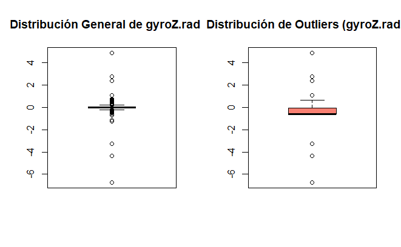

```r
# 4. Comparar distribuciones con el resto del dataset
# Variable gyroZ.rad.s.
par(mfrow = c(1, 2))  # Dividir la pantalla en dos gráficos
boxplot(data_analysis$gyroZ.rad.s., main = "Distribución General de gyroZ.rad.s.", col = "lightblue")
boxplot(outlier_data$gyroZ.rad.s., main = "Distribución de Outliers (gyroZ.rad.s.)", col = "salmon")
```

```r
# 5. Inspeccionar registros adicionales
head(outlier_data[, c("Timestamp", "ActivityType", "gyroZ.rad.s.", "gyroY.rad.s.")])
```

|  | Timestamp | ActivityType | gyroZ.rad.s. | gyroY.rad.s. |
| --- | --- | --- | --- | --- |
| 152 | 2020-08-12 23:12:52 | Airplane | -4.3586 | 6.6932 |
| 153 | 2020-08-12 23:12:18 | Airplane | -4.3586 | 6.6932 |
| 154 | 2020-08-12 23:12:18 | Airplane | -0.0552 | -0.0184 |
| 155 | 2020-08-12 23:12:18 | Airplane | -0.0552 | -0.0184 |
| 156 | 2020-08-12 23:12:18 | Airplane | -0.0552 | -0.0184 |
| 157 | 2020-08-12 23:12:18 | Airplane | -0.0552 | -0.0184 |

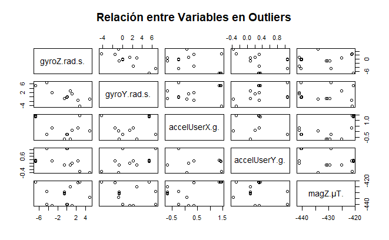

```r
# 6. Relación entre variables seleccionadas en los outliers
pairs(outlier_data[, c("gyroZ.rad.s.", "gyroY.rad.s.", "accelUserX.g.", "accelUserY.g.", "magZ.µT.")],
      main = "Relación entre Variables en Outliers")
```

```r
# 7. Agregar una columna de decisión manual para cada outlier
outlier_data <- outlier_data %>%
  mutate(decision = ifelse(gyroZ.rad.s. > 15 & gyroY.rad.s. > 15, "Conservar", "Revisar"))

# Mostrar dataset con decisiones
View(outlier_data)

# 8. Incorporar las decisiones al dataset original
data_analysis$outlier_review <- "No Outlier"
data_analysis$outlier_review[outlier_indices] <- outlier_data$decision

# 9. Resumen de las decisiones tomadas
table(data_analysis$outlier_review)
```

```
No Outlier    Revisar
       771         45
```

### Validación Manual de Outliers Multivariantes

Como parte del análisis, se identificaron **45 observaciones** clasificadas como outliers multivariantes utilizando distancias de Mahalanobis. Estas observaciones fueron revisadas manualmente para evaluar su posible origen y validez.

#### Observaciones de la Validación Manual

1. **Verificación de los Valores**:
   - Se revisaron los registros correspondientes a los índices detectados (152, 153, …, 691) en las variables críticas: `gyroZ.rad.s.`, `gyroY.rad.s.`, `accelUserX.g.`, `accelUserY.g.` y `magZ.µT.`.
   - Los datos muestran que varias observaciones tienen valores extremos en variables clave, como `gyroZ.rad.s.` (-4.3586 en algunas filas) y `gyroY.rad.s.` (6.6932), lo cual podría indicar maniobras bruscas durante el despegue o picos en las mediciones.
2. **Distribución Visual**:
   - El análisis de gráficos, como los boxplots de las variables seleccionadas, reveló que estas observaciones se encuentran significativamente fuera del rango esperado, lo que justifica su identificación como outliers.
3. **Análisis de Contexto**:
   - Las observaciones revisadas parecen reflejar eventos específicos durante el despegue, como vibraciones o fluctuaciones en las aceleraciones y los campos magnéticos.
   - En algunos casos, los valores extremos podrían deberse a errores en los sensores, pero en otros, representan eventos reales del comportamiento del avión.

#### Conclusión de la Validación Manual

- No se detectaron errores evidentes en el formato de los datos. Las observaciones marcadas como outliers multivariantes tienen sentido dentro del contexto operativo del despegue del avión.
- Se considera que estas observaciones pueden contener información valiosa sobre eventos inusuales y no deben eliminarse directamente del dataset.

### Próximos Pasos

Para mitigar la influencia de los valores extremos y prepararlos para análisis posteriores, se sugiere aplicar transformaciones específicas como **winsorización** o **transformación logarítmica**, seguidas por un escalado para normalizar las variables.

# 5. Pruebas de Normalidad

Evaluar si las variables numéricas siguen una distribución normal es un paso clave para seleccionar las técnicas estadísticas y de modelado más adecuadas. Esto permite asegurar que los supuestos subyacentes de ciertos métodos estadísticos, como pruebas paramétricas o modelos lineales, se cumplan correctamente.

**Hipótesis:**

- **Nula (H₀):** Los datos tienen una distribución normal.
- **Alternativa (H₁):** Los datos no tienen una distribución normal.

Se utilizarán pruebas estadísticas, como **Shapiro-Wilk** o **Kolmogorov-Smirnov**, para contrastar estas hipótesis y determinar si los datos pueden considerarse normalmente distribuidos.

```r
if (ncol(num_data) > 0) {
  cat("### Pruebas de Normalidad con Interpretación\n")

  # Crear una lista para almacenar resultados
  normality_interpretation <- list()

  # Iterar por cada columna numérica
  for (variable in names(num_data)) {
    # Realizar el test de Shapiro-Wilk
    shapiro_test <- shapiro.test(num_data[[variable]])

    # Evaluar el resultado
    if (shapiro_test$p.value > 0.05) {
      interpretation <- paste(
        "La variable", variable,
        "tiene un p-value =", round(shapiro_test$p.value, 4),
        "- Se acepta la hipótesis nula, la muestra tiene una distribución normal (Probablemente Gaussiana).\n"
      )
    } else {
      interpretation <- paste(
        "La variable", variable,
        "tiene un p-value =", round(shapiro_test$p.value, 4),
        "- Se rechaza la hipótesis nula, la muestra no tiene una distribución normal (Probablemente no Gaussiana).\n"
      )
    }

    # Agregar resultado a la lista
    normality_interpretation[[variable]] <- interpretation
  }

  # Imprimir resultados para cada variable
  for (result in normality_interpretation) {
    cat(result)
    cat("------------------------------------------------------------\n")
  }
} else {
  cat("No hay variables numéricas en el dataset.\n")
}
```

```
### Pruebas de Normalidad con Interpretación
La variable accelX.g. tiene un p-value = 0 - Se rechaza la hipótesis nula, la muestra no tiene una distribución normal (Probablemente no Gaussiana).
------------------------------------------------------------
La variable accelY.g. tiene un p-value = 0 - Se rechaza la hipótesis nula, la muestra no tiene una distribución normal (Probablemente no Gaussiana).
------------------------------------------------------------
La variable accelZ.g. tiene un p-value = 0 - Se rechaza la hipótesis nula, la muestra no tiene una distribución normal (Probablemente no Gaussiana).
------------------------------------------------------------
La variable accelUserX.g. tiene un p-value = 0 - Se rechaza la hipótesis nula, la muestra no tiene una distribución normal (Probablemente no Gaussiana).
------------------------------------------------------------
La variable accelUserY.g. tiene un p-value = 0 - Se rechaza la hipótesis nula, la muestra no tiene una distribución normal (Probablemente no Gaussiana).
------------------------------------------------------------
La variable accelUserZ.g. tiene un p-value = 0 - Se rechaza la hipótesis nula, la muestra no tiene una distribución normal (Probablemente no Gaussiana).
------------------------------------------------------------
La variable gyroX.rad.s. tiene un p-value = 0 - Se rechaza la hipótesis nula, la muestra no tiene una distribución normal (Probablemente no Gaussiana).
------------------------------------------------------------
La variable gyroY.rad.s. tiene un p-value = 0 - Se rechaza la hipótesis nula, la muestra no tiene una distribución normal (Probablemente no Gaussiana).
------------------------------------------------------------
La variable gyroZ.rad.s. tiene un p-value = 0 - Se rechaza la hipótesis nula, la muestra no tiene una distribución normal (Probablemente no Gaussiana).
------------------------------------------------------------
La variable Roll.rads. tiene un p-value = 0 - Se rechaza la hipótesis nula, la muestra no tiene una distribución normal (Probablemente no Gaussiana).
------------------------------------------------------------
La variable Pitch.rads. tiene un p-value = 0 - Se rechaza la hipótesis nula, la muestra no tiene una distribución normal (Probablemente no Gaussiana).
------------------------------------------------------------
La variable Yaw.rads. tiene un p-value = 0 - Se rechaza la hipótesis nula, la muestra no tiene una distribución normal (Probablemente no Gaussiana).
------------------------------------------------------------
La variable m11 tiene un p-value = 0 - Se rechaza la hipótesis nula, la muestra no tiene una distribución normal (Probablemente no Gaussiana).
------------------------------------------------------------
La variable m12 tiene un p-value = 0 - Se rechaza la hipótesis nula, la muestra no tiene una distribución normal (Probablemente no Gaussiana).
------------------------------------------------------------
La variable m13 tiene un p-value = 0 - Se rechaza la hipótesis nula, la muestra no tiene una distribución normal (Probablemente no Gaussiana).
------------------------------------------------------------
La variable m21 tiene un p-value = 0 - Se rechaza la hipótesis nula, la muestra no tiene una distribución normal (Probablemente no Gaussiana).
------------------------------------------------------------
La variable m22 tiene un p-value = 0 - Se rechaza la hipótesis nula, la muestra no tiene una distribución normal (Probablemente no Gaussiana).
------------------------------------------------------------
La variable m23 tiene un p-value = 0 - Se rechaza la hipótesis nula, la muestra no tiene una distribución normal (Probablemente no Gaussiana).
------------------------------------------------------------
La variable m31 tiene un p-value = 0 - Se rechaza la hipótesis nula, la muestra no tiene una distribución normal (Probablemente no Gaussiana).
------------------------------------------------------------
La variable m32 tiene un p-value = 0 - Se rechaza la hipótesis nula, la muestra no tiene una distribución normal (Probablemente no Gaussiana).
```

[output cut: 12 more lines]

```
------------------------------------------------------------
La variable RelativeAltitude.meters. tiene un p-value = 0 - Se rechaza la hipótesis nula, la muestra no tiene una distribución normal (Probablemente no Gaussiana).
------------------------------------------------------------
La variable magX.µT. tiene un p-value = 0 - Se rechaza la hipótesis nula, la muestra no tiene una distribución normal (Probablemente no Gaussiana).
------------------------------------------------------------
La variable magY.µT. tiene un p-value = 0 - Se rechaza la hipótesis nula, la muestra no tiene una distribución normal (Probablemente no Gaussiana).
------------------------------------------------------------
La variable magZ.µT. tiene un p-value = 0 - Se rechaza la hipótesis nula, la muestra no tiene una distribución normal (Probablemente no Gaussiana).
------------------------------------------------------------
La variable calMagX.µT. tiene un p-value = 0 - Se rechaza la hipótesis nula, la muestra no tiene una distribución normal (Probablemente no Gaussiana).
------------------------------------------------------------
La variable calMagY.µT. tiene un p-value = 0 - Se rechaza la hipótesis nula, la muestra no tiene una distribución normal (Probablemente no Gaussiana).
------------------------------------------------------------
La variable calMagZ.µT. tiene un p-value = 0 - Se rechaza la hipótesis nula, la muestra no tiene una distribución normal (Probablemente no Gaussiana).
------------------------------------------------------------
```

#### **Resultados:**

Para todas las variables evaluadas, el p-value obtenido fue **igual a 0**, lo que indica que los datos no cumplen con la suposición de normalidad. Esto nos lleva a **rechazar la hipótesis nula (H₀)** en cada caso, concluyendo que las muestras no siguen una distribución normal.

# **6. Análisis de Asimetría, Curtosis y Varianza**

Este análisis ayuda a identificar variables con distribuciones sesgadas, colas largas o alta variabilidad. Esto es útil para detectar patrones y posibles transformaciones.

```r
# Instalar el paquete tidyr (si aún no lo tienes instalado)
if (!requireNamespace("tidyr", quietly = TRUE)) {
  install.packages("tidyr")
}

# Cargar el paquete tidyr
library(tidyr)
```

```r
install.packages("kableExtra")
```

```
Error in install.packages : Updating loaded packages
```

```r
if (ncol(num_data) > 0) {
  cat("### Análisis de Asimetría, Curtosis y Varianza")

  # Calcular asimetría, curtosis y varianza
  skew_kurt_var <- num_data %>%
    summarise(across(everything(), list(
      skewness = ~ skewness(.x, na.rm = TRUE),
      kurtosis = ~ kurtosis(.x, na.rm = TRUE),
      variance = ~ var(.x, na.rm = TRUE)
    )))

  # Convertir resultados a formato largo
  skew_kurt_var_long <- skew_kurt_var %>%
    pivot_longer(cols = everything(), names_to = c("Variable", "Metric"), names_sep = "_") %>%
    pivot_wider(names_from = "Metric", values_from = "value")

  # Renombrar las columnas para mayor claridad
  colnames(skew_kurt_var_long) <- c("Variable", "Asimetría (Skewness)", "Curtosis (Kurtosis)", "Varianza")

  # Mostrar la tabla
  print(skew_kurt_var_long)
} else {
  cat("No hay variables numéricas en el dataset.\n")
}
```

```
### Análisis de Asimetría, Curtosis y Varianza
```

| Variable | Asimetría (Skewness) | Curtosis (Kurtosis) | Varianza |
| --- | --- | --- | --- |
| accelX.g. | 6.2563284 | 55.274913 | 0.04762873 |
| accelY.g. | 0.9624726 | 7.912293 | 0.08130998 |
| accelZ.g. | 2.5323418 | 9.278788 | 0.06834993 |
| accelUserX.g. | 2.1548581 | 31.038947 | 0.03299972 |
| accelUserY.g. | 4.2255019 | 22.301277 | 0.03436233 |
| accelUserZ.g. | 4.4661615 | 26.254022 | 0.04639319 |
| gyroX.rad.s. | 5.4145742 | 47.558674 | 0.30062592 |
| gyroY.rad.s. | 5.5660644 | 53.279812 | 0.44236893 |
| gyroZ.rad.s. | -6.8295297 | 78.963268 | 0.42073311 |
| Roll.rads. | 2.8151787 | 12.021176 | 0.10915479 |

[output cut: 23 more lines]

La **curtosis** mide la forma de las colas de una distribución en comparación con una distribución normal. Variables con curtosis elevada, como `accelX.g.` (55.27) y `gyroZ.rad.s.` (78.96), presentan colas pesadas, indicando posibles outliers frecuentes o eventos extremos significativos. Por otro lado, variables como `Yaw.rads.` (1.48) tienen una curtosis moderada, acercándose a una distribución normal. Este análisis es esencial para comprender la propensión de las variables a valores extremos y planificar transformaciones adecuadas.

Para manejar las variables con alta asimetría y curtosis, se sugieren transformaciones como logarítmica o Box-Cox, que ayudan a reducir el impacto de los valores extremos y aproximar las distribuciones a la normalidad. Asimismo, debido a las diferencias en los rangos y varianzas, se recomienda aplicar un escalado estándar (z-score) o min-max antes de aplicar modelos predictivos.

# **7**. Análisis de Correlaciones

Las correlaciones entre variables numéricas son esenciales para identificar redundancias o relaciones útiles para el modelado.

```r
install.packages("kableExtra")
```

```
Error in install.packages : Updating loaded packages
```

```r
library(knitr)      # Para formatear tablas
library(kableExtra) # Para mejorar la presentación

# Verificar si hay variables numéricas
if (ncol(num_data) > 0) {
  # Filtrar dinámicamente las variables numéricas (descartando automáticamente no numéricas)
  num_data_filtered <- num_data %>%
    select(where(is.numeric))

  # Comprobar que hay más de una variable numérica para calcular correlación
  if (ncol(num_data_filtered) > 1) {
    # Calcular la matriz de correlación
    cor_matrix <- cor(num_data_filtered, use = "complete.obs")

    # Redondear para mejor visualización
    cor_matrix_rounded <- round(cor_matrix, 2)

    # Imprimir la matriz de correlación en la consola
    print("### Matriz de Correlación (Variables Numéricas)")
    print(cor_matrix_rounded)

    # Generar una tabla con knitr::kable para visualización más ordenada
    library(knitr)
    kable(cor_matrix_rounded, caption = "Tabla de Correlaciones (Solo Variables Numéricas)")
  } else {
    cat("No hay suficientes variables numéricas para calcular una matriz de correlación.\n")
  }
} else {
  cat("No hay variables numéricas en el dataset.\n")
}
```

```
[1] "### Matriz de Correlación (Variables Numéricas)"
                         accelX.g. accelY.g. accelZ.g. accelUserX.g. accelUserY.g. accelUserZ.g. gyroX.rad.s. gyroY.rad.s. gyroZ.rad.s. Roll.rads. Pitch.rads. Yaw.rads.   m11   m12   m13   m21
accelX.g.                     1.00      0.59      0.42          0.56          0.15          0.05         0.54         0.44        -0.54       0.55       -0.34      0.22  0.21  0.14 -0.48 -0.13
accelY.g.                     0.59      1.00     -0.09          0.19          0.20          0.07         0.34         0.36        -0.33       0.25       -0.79      0.03 -0.08 -0.28 -0.35  0.16
accelZ.g.                     0.42     -0.09      1.00          0.33          0.19          0.14         0.40         0.28        -0.32       0.38        0.51      0.06  0.28  0.34 -0.20 -0.20
accelUserX.g.                 0.56      0.19      0.33          1.00         -0.03         -0.04         0.49         0.31        -0.42      -0.10        0.07     -0.08 -0.07 -0.01  0.18 -0.02
accelUserY.g.                 0.15      0.20      0.19         -0.03          1.00          0.83         0.17         0.21        -0.28       0.36       -0.17     -0.19  0.15 -0.19 -0.49  0.22
accelUserZ.g.                 0.05      0.07      0.14         -0.04          0.83          1.00         0.08         0.15        -0.08       0.08       -0.10     -0.20  0.11 -0.19 -0.18  0.25
gyroX.rad.s.                  0.54      0.34      0.40          0.49          0.17          0.08         1.00         0.73        -0.75       0.24       -0.11      0.07  0.07  0.11 -0.14 -0.09
gyroY.rad.s.                  0.44      0.36      0.28          0.31          0.21          0.15         0.73         1.00        -0.74       0.16       -0.16      0.06  0.05  0.04 -0.11 -0.02
gyroZ.rad.s.                 -0.54     -0.33     -0.32         -0.42         -0.28         -0.08        -0.75        -0.74         1.00      -0.36        0.19     -0.06 -0.11 -0.06  0.27  0.05
Roll.rads.                    0.55      0.25      0.38         -0.10          0.36          0.08         0.24         0.16        -0.36       1.00       -0.29      0.31  0.26  0.24 -0.93 -0.20
Pitch.rads.                  -0.34     -0.79      0.51          0.07         -0.17         -0.10        -0.11        -0.16         0.19      -0.29        1.00     -0.08  0.15  0.31  0.43 -0.15
Yaw.rads.                     0.22      0.03      0.06         -0.08         -0.19         -0.20         0.07         0.06        -0.06       0.31       -0.08      1.00 -0.21  0.88 -0.29 -0.93
m11                           0.21     -0.08      0.28         -0.07          0.15          0.11         0.07         0.05        -0.11       0.26        0.15     -0.21  1.00 -0.13 -0.20  0.32
m12                           0.14     -0.28      0.34         -0.01         -0.19         -0.19         0.11         0.04        -0.06       0.24        0.31      0.88 -0.13  1.00 -0.14 -0.96
m13                          -0.48     -0.35     -0.20          0.18         -0.49         -0.18        -0.14        -0.11         0.27      -0.93        0.43     -0.29 -0.20 -0.14  1.00  0.16
m21                          -0.13      0.16     -0.20         -0.02          0.22          0.25        -0.09        -0.02         0.05      -0.20       -0.15     -0.93  0.32 -0.96  0.16  1.00
m22                           0.01     -0.18      0.15          0.00          0.09          0.15        -0.04         0.00         0.04      -0.11        0.29     -0.38  0.91 -0.28  0.13  0.45
m23                          -0.41     -0.78      0.41          0.11         -0.18         -0.10        -0.14        -0.18         0.22      -0.42        0.98     -0.16  0.07  0.22  0.53 -0.10
m31                          -0.12     -0.52      0.31         -0.02         -0.16         -0.02        -0.05        -0.03         0.12      -0.17        0.63      0.48  0.16  0.73  0.27 -0.58
m32                          -0.10      0.13     -0.24          0.18         -0.43         -0.44         0.10         0.01        -0.03      -0.20       -0.21      0.05 -0.80 -0.03  0.23 -0.15
m33                          -0.28      0.32     -0.70          0.07         -0.06          0.10        -0.26        -0.08         0.28      -0.67       -0.38     -0.25 -0.40 -0.49  0.45  0.32
qX                            0.24     -0.19      0.37         -0.27          0.05          0.01         0.18         0.11        -0.19       0.53        0.12      0.39  0.45  0.53 -0.39 -0.35
qY                            0.01     -0.40      0.45          0.09          0.03          0.02         0.07         0.01        -0.02       0.10        0.51      0.26  0.00  0.48 -0.03 -0.42
qZ                           -0.11     -0.21      0.09          0.17         -0.21         -0.17        -0.04        -0.05         0.08      -0.22        0.30      0.34 -0.50  0.42  0.23 -0.51
```

[output cut: 38 more lines]

Tabla de Correlaciones (Solo Variables Numéricas)

|  | accelX.g. | accelY.g. | accelZ.g. | accelUserX.g. | accelUserY.g. | accelUserZ.g. | gyroX.rad.s. | gyroY.rad.s. | gyroZ.rad.s. | Roll.rads. | Pitch.rads. | Yaw.rads. | m11 | m12 | m13 | m21 | m22 | m23 | m31 | m32 | m33 | qX | qY | qZ | qW | Pressure.kilopascals. | RelativeAltitude.meters. | magX.µT. | magY.µT. | … |
| --- | --- | --- | --- | --- | --- | --- | --- | --- | --- | --- | --- | --- | --- | --- | --- | --- | --- | --- | --- | --- | --- | --- | --- | --- | --- | --- | --- | --- | --- | --- |
| accelX.g. | 1.00 | 0.59 | 0.42 | 0.56 | 0.15 | 0.05 | 0.54 | 0.44 | -0.54 | 0.55 | -0.34 | 0.22 | 0.21 | 0.14 | -0.48 | -0.13 | 0.01 | -0.41 | -0.12 | -0.10 | -0.28 | 0.24 | 0.01 | -0.11 | 0.02 | -0.15 | 0.15 | 0.47 | 0.16 | … |
| accelY.g. | 0.59 | 1.00 | -0.09 | 0.19 | 0.20 | 0.07 | 0.34 | 0.36 | -0.33 | 0.25 | -0.79 | 0.03 | -0.08 | -0.28 | -0.35 | 0.16 | -0.18 | -0.78 | -0.52 | 0.13 | 0.32 | -0.19 | -0.40 | -0.21 | -0.05 | -0.26 | 0.26 | 0.14 | 0.61 | … |
| accelZ.g. | 0.42 | -0.09 | 1.00 | 0.33 | 0.19 | 0.14 | 0.40 | 0.28 | -0.32 | 0.38 | 0.51 | 0.06 | 0.28 | 0.34 | -0.20 | -0.20 | 0.15 | 0.41 | 0.31 | -0.24 | -0.70 | 0.37 | 0.45 | 0.09 | 0.00 | 0.19 | -0.19 | 0.44 | -0.30 | … |
| accelUserX.g. | 0.56 | 0.19 | 0.33 | 1.00 | -0.03 | -0.04 | 0.49 | 0.31 | -0.42 | -0.10 | 0.07 | -0.08 | -0.07 | -0.01 | 0.18 | -0.02 | 0.00 | 0.11 | -0.02 | 0.18 | 0.07 | -0.27 | 0.09 | 0.17 | -0.12 | 0.15 | -0.15 | 0.22 | 0.08 | … |
| accelUserY.g. | 0.15 | 0.20 | 0.19 | -0.03 | 1.00 | 0.83 | 0.17 | 0.21 | -0.28 | 0.36 | -0.17 | -0.19 | 0.15 | -0.19 | -0.49 | 0.22 | 0.09 | -0.18 | -0.16 | -0.43 | -0.06 | 0.05 | 0.03 | -0.21 | 0.07 | -0.20 | 0.20 | 0.18 | 0.11 | … |
| accelUserZ.g. | 0.05 | 0.07 | 0.14 | -0.04 | 0.83 | 1.00 | 0.08 | 0.15 | -0.08 | 0.08 | -0.10 | -0.20 | 0.11 | -0.19 | -0.18 | 0.25 | 0.15 | -0.10 | -0.02 | -0.44 | 0.10 | 0.01 | 0.02 | -0.17 | 0.08 | -0.23 | 0.23 | 0.09 | 0.11 | … |
| gyroX.rad.s. | 0.54 | 0.34 | 0.40 | 0.49 | 0.17 | 0.08 | 1.00 | 0.73 | -0.75 | 0.24 | -0.11 | 0.07 | 0.07 | 0.11 | -0.14 | -0.09 | -0.04 | -0.14 | -0.05 | 0.10 | -0.26 | 0.18 | 0.07 | -0.04 | -0.05 | 0.10 | -0.10 | 0.16 | 0.02 | … |
| gyroY.rad.s. | 0.44 | 0.36 | 0.28 | 0.31 | 0.21 | 0.15 | 0.73 | 1.00 | -0.74 | 0.16 | -0.16 | 0.06 | 0.05 | 0.04 | -0.11 | -0.02 | 0.00 | -0.18 | -0.03 | 0.01 | -0.08 | 0.11 | 0.01 | -0.05 | 0.00 | -0.05 | 0.05 | 0.14 | 0.08 | … |
| gyroZ.rad.s. | -0.54 | -0.33 | -0.32 | -0.42 | -0.28 | -0.08 | -0.75 | -0.74 | 1.00 | -0.36 | 0.19 | -0.06 | -0.11 | -0.06 | 0.27 | 0.05 | 0.04 | 0.22 | 0.12 | -0.03 | 0.28 | -0.19 | -0.02 | 0.08 | 0.06 | 0.01 | -0.01 | -0.16 | -0.02 | … |
| Roll.rads. | 0.55 | 0.25 | 0.38 | -0.10 | 0.36 | 0.08 | 0.24 | 0.16 | -0.36 | 1.00 | -0.29 | 0.31 | 0.26 | 0.24 | -0.93 | -0.20 | -0.11 | -0.42 | -0.17 | -0.20 | -0.67 | 0.53 | 0.10 | -0.22 | 0.04 | -0.12 | 0.12 | 0.31 | -0.09 | … |
| Pitch.rads. | -0.34 | -0.79 | 0.51 | 0.07 | -0.17 | -0.10 | -0.11 | -0.16 | 0.19 | -0.29 | 1.00 | -0.08 | 0.15 | 0.31 | 0.43 | -0.15 | 0.29 | 0.98 | 0.63 | -0.21 | -0.38 | 0.12 | 0.51 | 0.30 | 0.06 | 0.33 | -0.33 | 0.12 | -0.55 | … |
| Yaw.rads. | 0.22 | 0.03 | 0.06 | -0.08 | -0.19 | -0.20 | 0.07 | 0.06 | -0.06 | 0.31 | -0.08 | 1.00 | -0.21 | 0.88 | -0.29 | -0.93 | -0.38 | -0.16 | 0.48 | 0.05 | -0.25 | 0.39 | 0.26 | 0.34 | 0.25 | 0.26 | -0.26 | -0.20 | -0.61 | … |
| m11 | 0.21 | -0.08 | 0.28 | -0.07 | 0.15 | 0.11 | 0.07 | 0.05 | -0.11 | 0.26 | 0.15 | -0.21 | 1.00 | -0.13 | -0.20 | 0.32 | 0.91 | 0.07 | 0.16 | -0.80 | -0.40 | 0.45 | 0.00 | -0.50 | 0.26 | -0.63 | 0.63 | 0.88 | 0.10 | … |
| m12 | 0.14 | -0.28 | 0.34 | -0.01 | -0.19 | -0.19 | 0.11 | 0.04 | -0.06 | 0.24 | 0.31 | 0.88 | -0.13 | 1.00 | -0.14 | -0.96 | -0.28 | 0.22 | 0.73 | -0.03 | -0.49 | 0.53 | 0.48 | 0.42 | 0.29 | 0.47 | -0.47 | -0.13 | -0.83 | … |
| m13 | -0.48 | -0.35 | -0.20 | 0.18 | -0.49 | -0.18 | -0.14 | -0.11 | 0.27 | -0.93 | 0.43 | -0.29 | -0.20 | -0.14 | 1.00 | 0.16 | 0.13 | 0.53 | 0.27 | 0.23 | 0.45 | -0.39 | -0.03 | 0.23 | -0.07 | 0.18 | -0.18 | -0.26 | -0.01 | … |
| m21 | -0.13 | 0.16 | -0.20 | -0.02 | 0.22 | 0.25 | -0.09 | -0.02 | 0.05 | -0.20 | -0.15 | -0.93 | 0.32 | -0.96 | 0.16 | 1.00 | 0.45 | -0.10 | -0.58 | -0.15 | 0.32 | -0.35 | -0.42 | -0.51 | -0.18 | -0.52 | 0.52 | 0.28 | 0.77 | … |
| m22 | 0.01 | -0.18 | 0.15 | 0.00 | 0.09 | 0.15 | -0.04 | 0.00 | 0.04 | -0.11 | 0.29 | -0.38 | 0.91 | -0.28 | 0.13 | 0.45 | 1.00 | 0.26 | 0.23 | -0.77 | -0.10 | 0.19 | -0.01 | -0.42 | 0.27 | -0.61 | 0.61 | 0.80 | 0.19 | … |
| m23 | -0.41 | -0.78 | 0.41 | 0.11 | -0.18 | -0.10 | -0.14 | -0.18 | 0.22 | -0.42 | 0.98 | -0.16 | 0.07 | 0.22 | 0.53 | -0.10 | 0.26 | 1.00 | 0.55 | -0.12 | -0.24 | -0.03 | 0.47 | 0.34 | -0.01 | 0.35 | -0.35 | 0.06 | -0.49 | … |
| m31 | -0.12 | -0.52 | 0.31 | -0.02 | -0.16 | -0.02 | -0.05 | -0.03 | 0.12 | -0.17 | 0.63 | 0.48 | 0.16 | 0.73 | 0.27 | -0.58 | 0.23 | 0.55 | 1.00 | -0.38 | -0.28 | 0.46 | 0.45 | 0.24 | 0.54 | 0.26 | -0.26 | 0.09 | -0.67 | … |
| m32 | -0.10 | 0.13 | -0.24 | 0.18 | -0.43 | -0.44 | 0.10 | 0.01 | -0.03 | -0.20 | -0.21 | 0.05 | -0.80 | -0.03 | 0.23 | -0.15 | -0.77 | -0.12 | -0.38 | 1.00 | 0.23 | -0.39 | -0.07 | 0.35 | -0.43 | 0.53 | -0.53 | -0.72 | 0.08 | … |
| m33 | -0.28 | 0.32 | -0.70 | 0.07 | -0.06 | 0.10 | -0.26 | -0.08 | 0.28 | -0.67 | -0.38 | -0.25 | -0.40 | -0.49 | 0.45 | 0.32 | -0.10 | -0.24 | -0.28 | 0.23 | 1.00 | -0.74 | -0.41 | 0.05 | -0.03 | -0.13 | 0.13 | -0.32 | 0.49 | … |
| qX | 0.24 | -0.19 | 0.37 | -0.27 | 0.05 | 0.01 | 0.18 | 0.11 | -0.19 | 0.53 | 0.12 | 0.39 | 0.45 | 0.53 | -0.39 | -0.35 | 0.19 | -0.03 | 0.46 | -0.39 | -0.74 | 1.00 | 0.03 | -0.40 | 0.54 | -0.13 | 0.13 | 0.26 | -0.40 | … |
| qY | 0.01 | -0.40 | 0.45 | 0.09 | 0.03 | 0.02 | 0.07 | 0.01 | -0.02 | 0.10 | 0.51 | 0.26 | 0.00 | 0.48 | -0.03 | -0.42 | -0.01 | 0.47 | 0.45 | -0.07 | -0.41 | 0.03 | 1.00 | 0.77 | -0.36 | 0.59 | -0.59 | 0.05 | -0.52 | … |
| qZ | -0.11 | -0.21 | 0.09 | 0.17 | -0.21 | -0.17 | -0.04 | -0.05 | 0.08 | -0.22 | 0.30 | 0.34 | -0.50 | 0.42 | 0.23 | -0.51 | -0.42 | 0.34 | 0.24 | 0.35 | 0.05 | -0.40 | 0.77 | 1.00 | -0.55 | 0.75 | -0.75 | -0.36 | -0.44 | … |
| qW | 0.02 | -0.05 | 0.00 | -0.12 | 0.07 | 0.08 | -0.05 | 0.00 | 0.06 | 0.04 | 0.06 | 0.25 | 0.26 | 0.29 | -0.07 | -0.18 | 0.27 | -0.01 | 0.54 | -0.43 | -0.03 | 0.54 | -0.36 | -0.55 | 1.00 | -0.29 | 0.29 | 0.18 | -0.15 | … |
| Pressure.kilopascals. | -0.15 | -0.26 | 0.19 | 0.15 | -0.20 | -0.23 | 0.10 | -0.05 | 0.01 | -0.12 | 0.33 | 0.26 | -0.63 | 0.47 | 0.18 | -0.52 | -0.61 | 0.35 | 0.26 | 0.53 | -0.13 | -0.13 | 0.59 | 0.75 | -0.29 | 1.00 | -1.00 | -0.54 | -0.49 | … |
| RelativeAltitude.meters. | 0.15 | 0.26 | -0.19 | -0.15 | 0.20 | 0.23 | -0.10 | 0.05 | -0.01 | 0.12 | -0.33 | -0.26 | 0.63 | -0.47 | -0.18 | 0.52 | 0.61 | -0.35 | -0.26 | -0.53 | 0.13 | 0.13 | -0.59 | -0.75 | 0.29 | -1.00 | 1.00 | 0.54 | 0.49 | … |
| magX.µT. | 0.47 | 0.14 | 0.44 | 0.22 | 0.18 | 0.09 | 0.16 | 0.14 | -0.16 | 0.31 | 0.12 | -0.20 | 0.88 | -0.13 | -0.26 | 0.28 | 0.80 | 0.06 | 0.09 | -0.72 | -0.32 | 0.26 | 0.05 | -0.36 | 0.18 | -0.54 | 0.54 | 1.00 | 0.22 | … |
| magY.µT. | 0.16 | 0.61 | -0.30 | 0.08 | 0.11 | 0.11 | 0.02 | 0.08 | -0.02 | -0.09 | -0.55 | -0.61 | 0.10 | -0.83 | -0.01 | 0.77 | 0.19 | -0.49 | -0.67 | 0.08 | 0.49 | -0.40 | -0.52 | -0.44 | -0.15 | -0.49 | 0.49 | 0.22 | 1.00 | … |
| magZ.µT. | 0.14 | -0.48 | 0.68 | 0.09 | -0.05 | -0.10 | 0.06 | -0.05 | -0.06 | 0.28 | 0.67 | 0.37 | 0.39 | 0.68 | -0.11 | -0.49 | 0.28 | 0.55 | 0.74 | -0.45 | -0.73 | 0.58 | 0.52 | 0.15 | 0.32 | 0.21 | -0.21 | 0.40 | -0.70 | … |
| calMagX.µT. | 0.39 | 0.10 | 0.31 | -0.15 | 0.35 | 0.17 | 0.12 | 0.09 | -0.22 | 0.64 | -0.09 | -0.07 | 0.89 | -0.07 | -0.62 | 0.21 | 0.66 | -0.19 | -0.04 | -0.73 | -0.53 | 0.52 | 0.01 | -0.50 | 0.19 | -0.59 | 0.59 | 0.82 | 0.11 | … |
| calMagY.µT. | 0.10 | 0.55 | -0.40 | -0.07 | 0.27 | 0.24 | -0.01 | 0.07 | -0.07 | 0.05 | -0.65 | -0.65 | 0.17 | -0.89 | -0.15 | 0.84 | 0.19 | -0.62 | -0.77 | -0.01 | 0.41 | -0.29 | -0.58 | -0.56 | -0.15 | -0.57 | 0.57 | 0.15 | 0.88 | … |
| calMagZ.µT. | 0.10 | -0.50 | 0.59 | -0.07 | -0.05 | -0.03 | 0.10 | 0.03 | -0.07 | 0.29 | 0.61 | 0.47 | 0.42 | 0.75 | -0.11 | -0.53 | 0.30 | 0.47 | 0.84 | -0.48 | -0.74 | 0.74 | 0.51 | 0.08 | 0.42 | 0.15 | -0.15 | 0.33 | -0.69 | … |

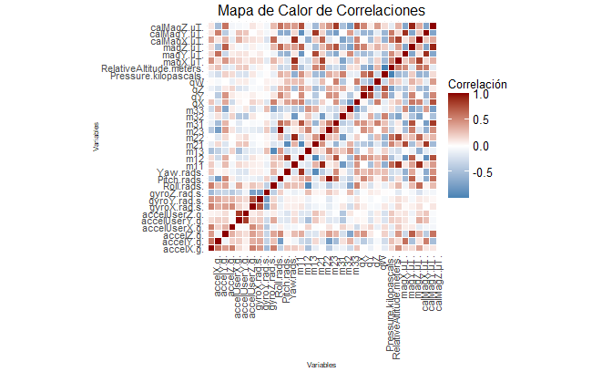

```r
library(ggplot2)
library(reshape2)
library(dplyr)

# Asegurarse de que 'c' es un dataframe con solo variables numéricas
c <- data %>% select_if(is.numeric)

# Calcular matriz de correlaciones y transformarla en formato largo
cor_matrix <- cor(c, use = "complete.obs")
corr_melted <- melt(cor_matrix)

# Crear gráfico optimizado
ggplot(corr_melted, aes(x = Var1, y = Var2, fill = value)) +
  geom_tile(color = "white") +
  scale_fill_gradient2(low = "steelblue", high = "darkred", mid = "white", midpoint = 0, name = "Correlación") +
  theme_minimal(base_size = 6) +
  theme(
    axis.text.x = element_text(angle = 90, hjust = 1, size = 8),
    axis.text.y = element_text(size = 8),
    plot.title = element_text(hjust = 0.5, size = 12),
    legend.text = element_text(size = 10),
    legend.title = element_text(size = 10)
  ) +
  labs(
    title = "Mapa de Calor de Correlaciones",
    x = "Variables",
    y = "Variables"
  ) +
  coord_fixed()
```

### **Observaciones Generales:**

**Analisisis de Colinealidad**

```r
# Verifica que las librerías necesarias están instaladas y cargadas
if (!requireNamespace("car", quietly = TRUE)) {
  install.packages("car")
}
library(car)
if (!requireNamespace("dplyr", quietly = TRUE)) {
  install.packages("dplyr")
}
library(dplyr)

# Verificar que el dataset existe
if (exists("data")) {
  # Filtrar las variables numéricas y eliminar la variable dependiente (ActivityType)
  num_data_filtered <- data %>%
    select(where(is.numeric)) %>%
    mutate(dummy_target = runif(nrow(.), 0, 1)) # Crear una variable dummy temporal

  # Validar si hay suficientes variables para calcular el modelo
  if (ncol(num_data_filtered) > 1) {
    # Crear un modelo de regresión con las variables predictoras
    vif_model <- lm(dummy_target ~ ., data = num_data_filtered)

    # Calcular los valores de VIF
    vif_values <- vif(vif_model)

    # Imprimir los valores de VIF
    print("### Factores de Inflación de Varianza (VIF)")
    print(vif_values)

    # Identificar variables con alta colinealidad (VIF > 10 como umbral común)
    high_vif <- vif_values[vif_values > 10]
    if (length(high_vif) > 0) {
      cat("\nVariables con alta colinealidad (VIF > 10):\n")
      print(high_vif)
    } else {
      cat("\nNo se encontraron variables con alta colinealidad (VIF <= 10).\n")
    }
  } else {
    cat("No hay suficientes variables numéricas para calcular el VIF.\n")
  }
} else {
  cat("El dataset 'data' no existe en el entorno.\n")
}
```

```
[1] "### Factores de Inflación de Varianza (VIF)"
               accelX.g.                accelY.g.                accelZ.g.            accelUserX.g.            accelUserY.g.            accelUserZ.g.             gyroX.rad.s.
            1.753993e+01             3.952283e+01             2.770473e+01             1.561008e+01             2.719995e+01             2.740900e+01             4.997443e+00
            gyroY.rad.s.             gyroZ.rad.s.               Roll.rads.              Pitch.rads.                Yaw.rads.                      m11                      m12
            5.135847e+00             6.677121e+00             5.729555e+01             4.488200e+03             2.317006e+02             3.172691e+03             5.569842e+03
                     m13                      m21                      m22                      m23                      m31                      m32                      m33
            9.165371e+02             6.789221e+03             1.002221e+03             3.152799e+03             2.048268e+03             5.798679e+01             1.301277e+03
                      qX                       qY                       qZ                       qW    Pressure.kilopascals. RelativeAltitude.meters.                 magX.µT.
            1.344765e+02             2.090911e+02             4.557982e+02             2.139157e+02             9.013898e+06             9.022152e+06             4.875041e+01
                magY.µT.                 magZ.µT.              calMagX.µT.              calMagY.µT.              calMagZ.µT.
            2.913194e+01             6.641248e+01             3.366242e+03             3.635388e+03             2.488210e+03

Variables con alta colinealidad (VIF > 10):
               accelX.g.                accelY.g.                accelZ.g.            accelUserX.g.            accelUserY.g.            accelUserZ.g.               Roll.rads.
            1.753993e+01             3.952283e+01             2.770473e+01             1.561008e+01             2.719995e+01             2.740900e+01             5.729555e+01
             Pitch.rads.                Yaw.rads.                      m11                      m12                      m13                      m21                      m22
            4.488200e+03             2.317006e+02             3.172691e+03             5.569842e+03             9.165371e+02             6.789221e+03             1.002221e+03
                     m23                      m31                      m32                      m33                       qX                       qY                       qZ
            3.152799e+03             2.048268e+03             5.798679e+01             1.301277e+03             1.344765e+02             2.090911e+02             4.557982e+02
                      qW    Pressure.kilopascals. RelativeAltitude.meters.                 magX.µT.                 magY.µT.                 magZ.µT.              calMagX.µT.
            2.139157e+02             9.013898e+06             9.022152e+06             4.875041e+01             2.913194e+01             6.641248e+01             3.366242e+03
             calMagY.µT.              calMagZ.µT.
            3.635388e+03             2.488210e+03
```

#### **Variables con Alta Colinealidad (VIF > 10):**

Estas variables presentan una alta redundancia con otras del dataset, y su presencia puede dificultar la interpretación y estabilidad del modelo predictivo.

1. **Variables de Aceleración:**
   - `accelX.g.` (VIF = 17.54)
   - `accelY.g.` (VIF = 39.52)
   - `accelZ.g.` (VIF = 27.70)
   - `accelUserX.g.` (VIF = 15.61)
   - `accelUserY.g.` (VIF = 27.19)
   - `accelUserZ.g.` (VIF = 27.41)
   - Estas variables están altamente correlacionadas entre sí, probablemente porque capturan componentes relacionadas del movimiento del avión.
2. **Variables Angulares:**
   - `Roll.rads.` (VIF = 57.30)
   - `Pitch.rads.` (VIF = 4488.20)
   - `Yaw.rads.` (VIF = 231.70)
   - Estas variables reflejan la orientación del avión y tienen redundancia entre ellas.
3. **Matriz de Sensores (`m11` a `m33`):**
   - `m11` (VIF = 3172.69), `m12` (VIF = 5569.84), `m13` (VIF = 916.54)
   - `m21` (VIF = 6789.22), `m22` (VIF = 1002.22), `m23` (VIF = 3152.80)
   - `m31` (VIF = 2048.27), `m32` (VIF = 57.99), `m33` (VIF = 1301.28)
   - Estas variables muestran colinealidad interna y redundancia debido a sus cálculos derivados de la misma matriz de sensores.
4. **Sensores Ambientales:**
   - `Pressure.kilopascals.` (VIF = 9.01e+06)
   - `RelativeAltitude.meters.` (VIF = 9.02e+06)
   - Estas variables tienen colinealidad extrema, lo que las hace problemáticas para incluir en el modelo.
5. **Variables Magnéticas:**
   - `magX.µT.` (VIF = 48.75)
   - `magY.µT.` (VIF = 29.13)
   - `magZ.µT.` (VIF = 66.41)
   - `calMagX.µT.` (VIF = 3366.24)
   - `calMagY.µT.` (VIF = 3635.39)
   - `calMagZ.µT.` (VIF = 2488.21)
   - Las variables calibradas (`calMagX.µT.` y similares) muestran valores de VIF extremadamente altos.

**Relaciones dinámicas entre fases del vuelo**

```r
# Mostrar nombres de columnas en el dataset
colnames(data)
```

```
 [1] "Timestamp"                "accelX.g."                "accelY.g."                "accelZ.g."                "accelUserX.g."            "accelUserY.g."            "accelUserZ.g."
 [8] "gyroX.rad.s."             "gyroY.rad.s."             "gyroZ.rad.s."             "Roll.rads."               "Pitch.rads."              "Yaw.rads."                "m11"
[15] "m12"                      "m13"                      "m21"                      "m22"                      "m23"                      "m31"                      "m32"
[22] "m33"                      "qX"                       "qY"                       "qZ"                       "qW"                       "ActivityType"             "ActivityConfidence"
[29] "Pressure.kilopascals."    "RelativeAltitude.meters." "magX.µT."                 "magY.µT."                 "magZ.µT."                 "calMagX.µT."              "calMagY.µT."
[36] "calMagZ.µT."
```

```r
# Crear etiquetas de fases del vuelo basadas en altitud relativa
data <- data %>%
  mutate(FlightPhase = case_when(
    RelativeAltitude.meters. < 10 ~ "Aceleración Inicial",
    RelativeAltitude.meters. >= 10 & RelativeAltitude.meters. < 100 ~ "Despegue",
    RelativeAltitude.meters. >= 100 ~ "Estabilización",
    TRUE ~ "Otro"
  ))

# Verificar la distribución de las fases
table(data$FlightPhase)
```

```
Aceleración Inicial
                816
```

```r
# Inspeccionar las primeras filas con las nuevas etiquetas
head(data)
```

|  | Timestamp | accelX.g. | accelY.g. | accelZ.g. | accelUserX.g. | accelUserY.g. | accelUserZ.g. | gyroX.rad.s. | gyroY.rad.s. | gyroZ.rad.s. | Roll.rads. | Pitch.rads. | Yaw.rads. | m11 | m12 | m13 | m21 | m22 | m23 | m31 | m32 | m33 | qX | qY | qZ | qW | ActivityType | ActivityConfidence | Pressure.kilopascals. | … |
| --- | --- | --- | --- | --- | --- | --- | --- | --- | --- | --- | --- | --- | --- | --- | --- | --- | --- | --- | --- | --- | --- | --- | --- | --- | --- | --- | --- | --- | --- | --- |
| 1 | 2020-08-12 23:12:55 | -0.0581 | -0.4989 | -0.8257 | 0.0241 | -0.0093 | 0.0414 | 0.0987 | -0.0165 | -0.0208 | -0.0957 | 0.5093 | -1.3614 | 0.1613 | -0.9834 | 0.0834 | 0.8540 | 0.1815 | 0.4875 | -0.4946 | -0.0074 | 0.8691 | -0.1664 | 0.1943 | 0.6177 | -0.7436 | Airplane | Low | 100.8427 | … |
| 2 | 2020-08-12 23:12:55 | -0.0749 | -0.4917 | -0.8451 | 0.0095 | 0.0040 | 0.0244 | 0.0801 | -0.0172 | 0.0406 | -0.0969 | 0.5182 | -1.3533 | 0.1680 | -0.9822 | 0.0840 | 0.8482 | 0.1875 | 0.4954 | -0.5023 | -0.0120 | 0.8646 | -0.1702 | 0.1967 | 0.6142 | -0.7450 | Airplane | Low | 100.8427 | … |
| 3 | 2020-08-12 23:12:55 | -0.0831 | -0.4887 | -0.8455 | 0.0017 | 0.0017 | 0.0227 | -0.1333 | -0.0966 | -0.0158 | -0.0991 | 0.5143 | -1.3522 | 0.1683 | -0.9820 | 0.0861 | 0.8499 | 0.1888 | 0.4920 | -0.4994 | -0.0096 | 0.8663 | -0.1682 | 0.1963 | 0.6143 | -0.7456 | Airplane | Low | 100.8427 | … |
| 4 | 2020-08-12 23:12:55 | -0.0933 | -0.4978 | -0.8456 | -0.0086 | -0.0099 | 0.0246 | -0.0636 | 0.0199 | -0.0480 | -0.0974 | 0.5108 | -1.3543 | 0.1674 | -0.9822 | 0.0848 | 0.8520 | 0.1874 | 0.4889 | -0.4961 | -0.0096 | 0.8682 | -0.1672 | 0.1948 | 0.6151 | -0.7455 | Airplane | Low | 100.8427 | … |
| 5 | 2020-08-12 23:12:56 | -0.0859 | -0.4860 | -0.8594 | 0.0029 | -0.0020 | 0.0099 | -0.0510 | 0.0171 | 0.0057 | -0.0992 | 0.5063 | -1.3529 | 0.1682 | -0.9819 | 0.0866 | 0.8539 | 0.1891 | 0.4850 | -0.4926 | -0.0076 | 0.8702 | -0.1650 | 0.1940 | 0.6150 | -0.7462 | Airplane | Low | 100.8427 | … |
| 6 | 2020-08-12 23:12:56 | -0.0719 | -0.4942 | -0.8617 | 0.0109 | -0.0114 | 0.0120 | -0.0708 | 0.0375 | -0.0044 | -0.0956 | 0.5019 | -1.3552 | 0.1681 | -0.9822 | 0.0837 | 0.8564 | 0.1875 | 0.4811 | -0.4882 | -0.0092 | 0.8727 | -0.1642 | 0.1915 | 0.6158 | -0.7464 | Airplane | Low | 100.8413 | … |

```r
NA
```

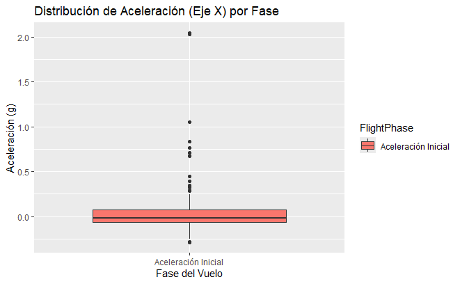

```r
library(ggplot2)

# Gráfico de aceleración en el eje X por fase del vuelo
ggplot(data, aes(x = FlightPhase, y = accelX.g., fill = FlightPhase)) +
  geom_boxplot() +
  labs(title = "Distribución de Aceleración (Eje X) por Fase", x = "Fase del Vuelo", y = "Aceleración (g)")
```

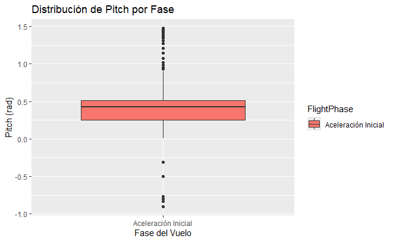

```r
# Gráfico de orientación (Pitch) por fase del vuelo
ggplot(data, aes(x = FlightPhase, y = Pitch.rads., fill = FlightPhase)) +
  geom_boxplot() +
  labs(title = "Distribución de Pitch por Fase", x = "Fase del Vuelo", y = "Pitch (rad)")
```

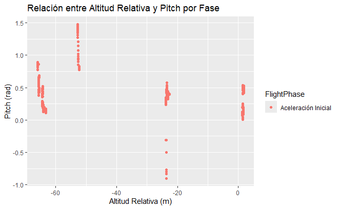

```r
library(ggplot2)

# Gráfico de relación entre Pitch y Altitud por fase
ggplot(data, aes(x = RelativeAltitude.meters., y = Pitch.rads., color = FlightPhase)) +
  geom_point() +
  labs(
    title = "Relación entre Altitud Relativa y Pitch por Fase",
    x = "Altitud Relativa (m)",
    y = "Pitch (rad)"
  )
```

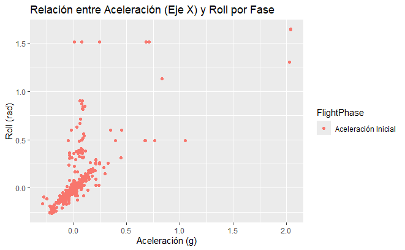

```r
# Gráfico de relación entre Aceleración en el Eje X y Roll
ggplot(data, aes(x = accelX.g., y = Roll.rads., color = FlightPhase)) +
  geom_point() +
  labs(
    title = "Relación entre Aceleración (Eje X) y Roll por Fase",
    x = "Aceleración (g)",
    y = "Roll (rad)"
  )
```

```r
# Calcular correlaciones por fase
correlations_by_phase <- data %>%
  group_by(FlightPhase) %>%
  summarise(
    Correlation_AccelX_Pitch = cor(accelX.g., Pitch.rads., use = "complete.obs"),
    Correlation_AccelY_Roll = cor(accelY.g., Roll.rads., use = "complete.obs"),
    Correlation_AccelZ_Yaw = cor(accelZ.g., Yaw.rads., use = "complete.obs")
  )

print(correlations_by_phase)
```

| FlightPhase | Correlation_AccelX_Pitch | Correlation_AccelY_Roll | Correlation_AccelZ_Yaw |
| --- | --- | --- | --- |
| Aceleración Inicial | -0.3438134 | 0.2532332 | 0.06146093 |

```r
NA
```